# Bremen Smart Governance: Complete Technical Analysis

## 1. Dataset Summary

Primary reporting year: 2024. Geographic level: Ortsteil. No imputation.

### Dataset counts

| Field | Value |
| --- | --- |
| Primary reporting year | 2024 |
| Workbook Ortsteile | 88 |
| Complete-case Ortsteile | 79 |
| Excluded Ortsteile | 9 |
| Baseline indicators | 3 |
| Imputed values | 0 |

### Statistical source observations, missing values and reporting years

| name | records | ok_values | missing_values | invalid_or_suppressed_values | duplicate_key_rows | unknown_geography_rows | years |
| --- | --- | --- | --- | --- | --- | --- | --- |
| csv_district_statistics_long.csv | 15147 | 14924 | 223 | 0 | 0 | 146 | 2010-2016 (6 reporting years) |
| excel_ortsteilatlas_long.csv | 316064 | 291709 | 24355 | 0 | 0 | 0 | 1969-2025 (50 reporting years) |

### Source reconstruction audit; JSON records are metadata

| check | source | passed | records | missing |
| --- | --- | --- | --- | --- |
| raw reconstruction equals existing processed output | excel_ortsteilatlas_long.csv | True | 316064 | 24355.000 |
| raw reconstruction equals existing processed output | csv_district_statistics_long.csv | True | 15147 | 223.000 |
| JSON metadata records readable separately | bremen_data.json | True | 1515 | Unavailable |

### Source inventory; catalogue years are title metadata, not observation years

| dataset_name | source_type | years | processed_records |
| --- | --- | --- | --- |
| ST111.csv | CSV district snapshot | 2010-2016 (6 reporting years) | 596 |
| ST121.csv | CSV district snapshot | 2010-2016 (6 reporting years) | 1350 |
| ST123.csv | CSV district snapshot | 2010-2016 (6 reporting years) | 745 |
| ST124.csv | CSV district snapshot | 2010-2016 (6 reporting years) | 750 |
| ST125.csv | CSV district snapshot | 2010-2016 (6 reporting years) | 441 |
| ST126.csv | CSV district snapshot | 2010-2016 (6 reporting years) | 144 |
| ST127.csv | CSV district snapshot | 2010-2016 (6 reporting years) | 143 |
| ST131.csv | CSV district snapshot | 2010-2016 (6 reporting years) | 735 |
| ST132.csv | CSV district snapshot | 2010-2016 (6 reporting years) | 1176 |
| ST133.csv | CSV district snapshot | 2010-2016 (6 reporting years) | 740 |
| ST134.csv | CSV district snapshot | 2010-2016 (6 reporting years) | 600 |
| ST135.csv | CSV district snapshot | 2010-2016 (6 reporting years) | 148 |
| ST136.csv | CSV district snapshot | 2010-2015 (5 reporting years) | 144 |
| ST137.csv | CSV district snapshot | 2010-2016 (6 reporting years) | 888 |
| ST138.csv | CSV district snapshot | 2010-2016 (6 reporting years) | 900 |
| ST141.csv | CSV district snapshot | 2010-2016 (6 reporting years) | 146 |
| ST142.csv | CSV district snapshot | 2010-2016 (6 reporting years) | 745 |
| ST143.csv | CSV district snapshot | 2010-2016 (6 reporting years) | 1168 |
| ST144.csv | CSV district snapshot | 2010-2016 (6 reporting years) | 894 |
| ST151.csv | CSV district snapshot | 2010-2016 (6 reporting years) | 894 |
| ST152.csv | CSV district snapshot | 2010-2016 (6 reporting years) | 900 |
| ST153.csv | CSV district snapshot | 2010-2016 (6 reporting years) | 900 |
| Datentabelle.xls::Gebiet und Fläche | Excel worksheet | 1988-2024 (26 reporting years) | 9184 |
| Datentabelle.xls::Bevölkerung (Absolute Werte) | Excel worksheet | 1974-2024 (19 reporting years) | 19152 |
| Datentabelle.xls::Altersstruktur I | Excel worksheet | 1974-2024 (19 reporting years) | 19152 |
| Datentabelle.xls::Altersstruktur II | Excel worksheet | 1974-2024 (19 reporting years) | 13888 |
| Datentabelle.xls::Familienstand und Wohndauer | Excel worksheet | 1980-2024 (25 reporting years) | 10304 |
| Datentabelle.xls::Ausländische Bevölkerung | Excel worksheet | 1974-2024 (27 reporting years) | 4368 |
| Datentabelle.xls::Migrationshintergrund | Excel worksheet | 2005-2024 (20 reporting years) | 24640 |
| Datentabelle.xls::Bevölkerungsbewegung | Excel worksheet | 1979-2024 (10 reporting years) | 1120 |
| Datentabelle.xls::Geburten und Sterbefälle | Excel worksheet | 1974-2024 (19 reporting years) | 10640 |
| Datentabelle.xls::Wanderungen | Excel worksheet | 2000-2024 (16 reporting years) | 10752 |
| Datentabelle.xls::Wanderungssalden | Excel worksheet | 2000-2024 (16 reporting years) | 10752 |
| Datentabelle.xls::Privathaushalte | Excel worksheet | 2005-2024 (20 reporting years) | 13440 |
| Datentabelle.xls::Kirche | Excel worksheet | 1994-2021 (17 reporting years) | 1904 |
| Datentabelle.xls::Bildung | Excel worksheet | 2012-2024 (13 reporting years) | 23744 |
| Datentabelle.xls::Erwerbstätigkeit, Arbeitslosig | Excel worksheet | 2009-2024 (16 reporting years) | 15232 |
| Datentabelle.xls::Betriebe und Beschäftigte | Excel worksheet | 2009-2021 (12 reporting years) | 14560 |
| Datentabelle.xls::Wohnungswesen I | Excel worksheet | 1988-2024 (18 reporting years) | 17472 |
| Datentabelle.xls::Wohnungswesen II (Ergebnisse d | Excel worksheet | 2011-2022 (2 reporting years) | 672 |
| Datentabelle.xls::Heizen und Energieträger (Erge | Excel worksheet | 2011-2022 (2 reporting years) | 1568 |
| Datentabelle.xls::Bautätigkeit | Excel worksheet | 1983-2023 (21 reporting years) | 4704 |
| Datentabelle.xls::Verkehr | Excel worksheet | 2005-2024 (20 reporting years) | 7616 |
| Datentabelle.xls::Gesundheit | Excel worksheet | 1983-2025 (21 reporting years) | 8624 |
| Datentabelle.xls::Sozialleistungen | Excel worksheet | 2005-2024 (20 reporting years) | 22400 |
| Datentabelle.xls::Lohn- und Einkommensteuer | Excel worksheet | 2001-2020 (12 reporting years) | 6720 |
| Datentabelle.xls::Insolvenzen | Excel worksheet | 2022-2024 (3 reporting years) | 336 |
| Datentabelle.xls::Bundestagswahlen | Excel worksheet | 1969-2025 (16 reporting years) | 23072 |
| Datentabelle.xls::Bürgerschaftswahlen | Excel worksheet | 1971-2023 (14 reporting years) | 20048 |
| bremen_data.json | JSON open-data metadata catalogue | 1991-2027 (31 reporting years) | 1515 |

### Excluded Ortsteile, 2024

| geo_code | geo_name | exclusion_reason |
| --- | --- | --- |
| 122 | Industriehäfen | unemployment:missing;employment:missing;benefit_receipt:missing |
| 124 | Neustädter Hafen | unemployment:missing;employment:missing;benefit_receipt:missing |
| 125 | Hohentorshafen | unemployment:missing;employment:missing;benefit_receipt:missing |
| 271 | Strom | unemployment:missing;employment:missing |
| 411 | Blockland | unemployment:missing;employment:missing |
| 424 | In den Hufen | unemployment:missing;employment:missing |
| 436 | Hohweg | unemployment:missing;employment:missing |
| 444 | In den Wischen | unemployment:missing;employment:missing;benefit_receipt:missing |
| 512 | Werderland | unemployment:missing;employment:missing |

### Validation metadata

| Field | Status |
| --- | --- |
| CSV format | CP1252; semicolon; decimal comma |
| Excel format | BIFF XLS; xlrd; numeric cells |
| Missing data | Retained; complete-case scoring |
| Aggregate geographic levels | Excluded from scoring |
| Name alias | Überseestadt / Ueberseestadt: code 437 |
| Historical change calculations | Not produced; boundary and definition stability unverified |
| Within-year reference dates | Unverified |

## 2. Indicators and Coverage

Baseline: unemployment, employment, benefit_receipt. Coverage proportions are fractions.

### Indicators: original names, units, available years and scoring direction

| feature | original_german_name | english_name | unit | available_years | role | disadvantage_direction |
| --- | --- | --- | --- | --- | --- | --- |
| unemployment | Anteil der Arbeitslosen an den sozialversicherungspflichtig Beschäftigten zuzüglich Arbeitslose (%) | Unemployment quotient (%) | % | 2009; 2010; 2011; 2012; 2013; 2014; 2015; 2016; 2017; 2018; 2019; 2020; 2021; 2022; 2023; 2024 | primary | higher |
| employment | Anteil der sozialversicherungspflichtig Beschäftigten an der Bevölkerung im Alter von 15 bis unter 65 Jahren (%) | Social-insurance employment (%) | % | 2009; 2010; 2011; 2012; 2013; 2014; 2015; 2016; 2017; 2018; 2019; 2020; 2021; 2022; 2023; 2024 | primary | lower |
| benefit_receipt | Anteil der Leistungsberechtigten (Grundsicherung für Arbeitsuchende, SGB II) an der Bevölkerung unter 65 Jahren (%) | SGB II receipt, under 65 (%) | % | 2005; 2006; 2007; 2008; 2009; 2010; 2011; 2012; 2013; 2014; 2015; 2016; 2017; 2018; 2019; 2020; 2021; 2022; 2023; 2024 | primary | higher |
| child_benefits | Anteil der Leistungsberechtigten (Grundsicherung für Arbeitsuchende, SGB II) an der Bevölkerung unter 15 Jahren (%) | SGB II receipt, under 15 (%) | % | 2005; 2006; 2007; 2008; 2009; 2010; 2011; 2012; 2013; 2014; 2015; 2016; 2017; 2018; 2019; 2020; 2021; 2022; 2023; 2024 | sensitivity | higher |
| income_median | Gesamtbetrag der Einkünfte je Steuerpflichtigen (1000 EUR): Median | Median income per taxpayer (1000 EUR) | 1000 EUR | 2001; 2004; 2007; 2010; 2013; 2014; 2015; 2016; 2017; 2018; 2019; 2020 | historical_context | lower |
| single_parents | Anteil der Alleinerziehenden an den Privathaushalten mit Hauptwohnsitz mit Kind(ern) (%) | Single-parent households (%) | % | 2005; 2006; 2007; 2008; 2009; 2010; 2011; 2012; 2013; 2014; 2015; 2016; 2017; 2018; 2019; 2020; 2021; 2022; 2023; 2024 | context_only | not_scored |

### Measurement definitions

| feature | measurement_definition |
| --- | --- |
| unemployment | Registered unemployed / (social-insurance employees + registered unemployed). |
| employment | Social-insurance employees at residence / population aged 15 to under 65; excludes self-employment and civil servants. |
| benefit_receipt | SGB II entitled recipients / population under 65. |
| child_benefits | SGB II entitled recipients under 15 / population under 15. |
| income_median | Median total income per taxpayer, thousand EUR. |
| single_parents | Single-parent households / main-residence households with children. |

### Indicator sources and latest coverage

| feature | source_file | source_sheet | latest_year | latest_covered | total_ortsteile | latest_coverage_proportion | latest_missing_rate |
| --- | --- | --- | --- | --- | --- | --- | --- |
| unemployment | Datentabelle.xls | Erwerbstätigkeit, Arbeitslosig | 2024 | 79 | 88 | 0.898 | 0.102 |
| employment | Datentabelle.xls | Erwerbstätigkeit, Arbeitslosig | 2024 | 79 | 88 | 0.898 | 0.102 |
| benefit_receipt | Datentabelle.xls | Sozialleistungen | 2024 | 84 | 88 | 0.955 | 0.045 |
| child_benefits | Datentabelle.xls | Sozialleistungen | 2024 | 84 | 88 | 0.955 | 0.045 |
| income_median | Datentabelle.xls | Lohn- und Einkommensteuer | 2020 | 84 | 88 | 0.955 | 0.045 |
| single_parents | Datentabelle.xls | Privathaushalte | 2024 | 83 | 88 | 0.943 | 0.057 |

### Coverage by indicator and reporting year

| feature | year | total_ortsteile | observed | coverage_proportion | missing | missing_rate |
| --- | --- | --- | --- | --- | --- | --- |
| unemployment | 2009 | 88 | 84 | 0.955 | 4 | 0.045 |
| unemployment | 2010 | 88 | 0 | 0.000 | 88 | 1.000 |
| unemployment | 2011 | 88 | 84 | 0.955 | 4 | 0.045 |
| unemployment | 2012 | 88 | 84 | 0.955 | 4 | 0.045 |
| unemployment | 2013 | 88 | 84 | 0.955 | 4 | 0.045 |
| unemployment | 2014 | 88 | 85 | 0.966 | 3 | 0.034 |
| unemployment | 2015 | 88 | 85 | 0.966 | 3 | 0.034 |
| unemployment | 2016 | 88 | 85 | 0.966 | 3 | 0.034 |
| unemployment | 2017 | 88 | 85 | 0.966 | 3 | 0.034 |
| unemployment | 2018 | 88 | 79 | 0.898 | 9 | 0.102 |
| unemployment | 2019 | 88 | 79 | 0.898 | 9 | 0.102 |
| unemployment | 2020 | 88 | 79 | 0.898 | 9 | 0.102 |
| unemployment | 2021 | 88 | 79 | 0.898 | 9 | 0.102 |
| unemployment | 2022 | 88 | 79 | 0.898 | 9 | 0.102 |
| unemployment | 2023 | 88 | 79 | 0.898 | 9 | 0.102 |
| unemployment | 2024 | 88 | 79 | 0.898 | 9 | 0.102 |
| employment | 2009 | 88 | 84 | 0.955 | 4 | 0.045 |
| employment | 2010 | 88 | 84 | 0.955 | 4 | 0.045 |
| employment | 2011 | 88 | 84 | 0.955 | 4 | 0.045 |
| employment | 2012 | 88 | 84 | 0.955 | 4 | 0.045 |
| employment | 2013 | 88 | 84 | 0.955 | 4 | 0.045 |
| employment | 2014 | 88 | 85 | 0.966 | 3 | 0.034 |
| employment | 2015 | 88 | 85 | 0.966 | 3 | 0.034 |
| employment | 2016 | 88 | 85 | 0.966 | 3 | 0.034 |
| employment | 2017 | 88 | 85 | 0.966 | 3 | 0.034 |
| employment | 2018 | 88 | 79 | 0.898 | 9 | 0.102 |
| employment | 2019 | 88 | 79 | 0.898 | 9 | 0.102 |
| employment | 2020 | 88 | 79 | 0.898 | 9 | 0.102 |
| employment | 2021 | 88 | 79 | 0.898 | 9 | 0.102 |
| employment | 2022 | 88 | 79 | 0.898 | 9 | 0.102 |

[output cut: 74 more lines]

## 3. Descriptive Statistics

2024; unweighted neighborhood statistics; sample standard deviation (ddof=1); rates in percent.

### Complete-case statistics, 2024; percent

| feature | count | mean | std | min | 25% | median | 75% | max |
| --- | --- | --- | --- | --- | --- | --- | --- | --- |
| unemployment | 79.000 | 11.862 | 5.554 | 2.590 | 7.409 | 10.976 | 16.170 | 27.541 |
| employment | 79.000 | 58.630 | 5.313 | 44.159 | 55.644 | 59.404 | 62.209 | 72.714 |
| benefit_receipt | 79.000 | 14.844 | 8.392 | 1.702 | 8.304 | 13.232 | 20.532 | 34.622 |

### Available-case statistics, 2024; percent

| feature | count | mean | std | min | 25% | median | 75% | max |
| --- | --- | --- | --- | --- | --- | --- | --- | --- |
| unemployment | 79.000 | 11.862 | 5.554 | 2.590 | 7.409 | 10.976 | 16.170 | 27.541 |
| employment | 79.000 | 58.630 | 5.313 | 44.159 | 55.644 | 59.404 | 62.209 | 72.714 |
| benefit_receipt | 84.000 | 14.329 | 8.571 | 0.990 | 6.573 | 12.469 | 20.104 | 34.622 |

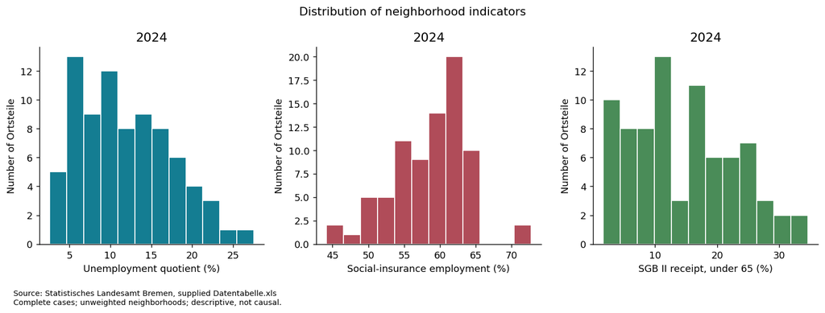

2024 indicator distributions; percent; complete cases.

### Spearman indicator correlations; unitless

| feature | unemployment | employment | benefit_receipt |
| --- | --- | --- | --- |
| unemployment | 1.000 | -0.667 | 0.974 |
| employment | -0.667 | 1.000 | -0.588 |
| benefit_receipt | 0.974 | -0.588 | 1.000 |

### Pearson indicator correlations; unitless

| feature | unemployment | employment | benefit_receipt |
| --- | --- | --- | --- |
| unemployment | 1.000 | -0.679 | 0.971 |
| employment | -0.679 | 1.000 | -0.602 |
| benefit_receipt | 0.971 | -0.602 | 1.000 |

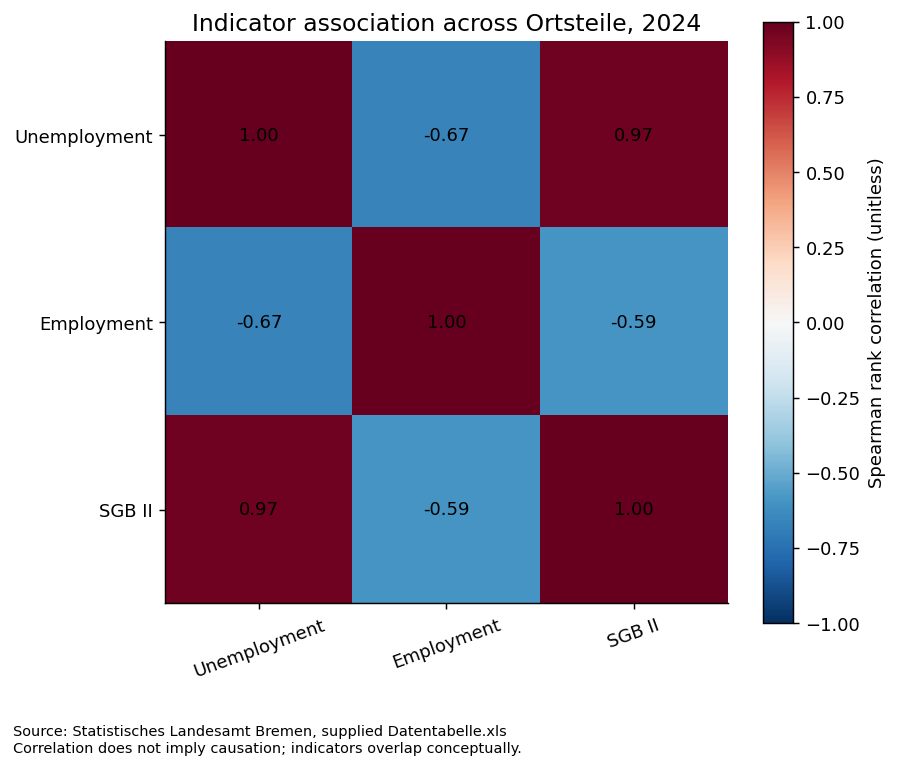

2024 Spearman correlations; unitless.

### 1.5-IQR flags; observations retained

| geo_code | geo_name | year | feature | value | lower_fence | upper_fence |
| --- | --- | --- | --- | --- | --- | --- |
| 252 | Rablinghausen | 2024 | employment | 72.401 | 45.797 | 72.056 |
| 261 | Seehausen | 2024 | employment | 72.714 | 45.797 | 72.056 |
| 522 | Grohn | 2024 | employment | 44.186 | 45.797 | 72.056 |
| 525 | Fähr-Lobbendorf | 2024 | employment | 44.159 | 45.797 | 72.056 |

## 4. Neighborhood Comparisons

2024 complete-case neighborhoods; 2020 income context shown separately.

### All included Ortsteile, 2024; indicator values in percent

| geo_code | geo_name | year | unemployment | employment | benefit_receipt |
| --- | --- | --- | --- | --- | --- |
| 111 | Altstadt | 2024 | 9.913 | 63.620 | 13.232 |
| 112 | Bahnhofsvorstadt | 2024 | 20.261 | 54.538 | 26.383 |
| 113 | Ostertor | 2024 | 9.740 | 56.038 | 9.368 |
| 211 | Alte Neustadt | 2024 | 10.775 | 63.061 | 11.807 |
| 212 | Hohentor | 2024 | 14.162 | 58.835 | 16.998 |
| 213 | Neustadt | 2024 | 8.540 | 59.404 | 9.146 |
| 214 | Südervorstadt | 2024 | 10.857 | 61.732 | 11.600 |
| 215 | Gartenstadt Süd | 2024 | 11.075 | 62.897 | 16.518 |
| 216 | Buntentor | 2024 | 9.159 | 62.254 | 9.200 |
| 217 | Neuenland | 2024 | 21.419 | 58.484 | 23.539 |
| 218 | Huckelriede | 2024 | 14.204 | 49.470 | 18.416 |
| 231 | Habenhausen | 2024 | 3.963 | 63.226 | 2.410 |
| 232 | Arsten | 2024 | 8.187 | 63.586 | 10.476 |
| 233 | Kattenturm | 2024 | 17.219 | 54.852 | 23.642 |
| 234 | Kattenesch | 2024 | 8.179 | 63.174 | 10.220 |
| 241 | Mittelshuchting | 2024 | 16.763 | 55.472 | 25.788 |
| 242 | Sodenmatt | 2024 | 18.321 | 55.169 | 26.838 |
| 243 | Kirchhuchting | 2024 | 18.968 | 51.741 | 25.884 |
| 244 | Grolland | 2024 | 5.155 | 63.804 | 4.378 |
| 251 | Woltmershausen | 2024 | 13.723 | 59.911 | 17.353 |
| 252 | Rablinghausen | 2024 | 9.073 | 72.401 | 10.984 |
| 261 | Seehausen | 2024 | 2.590 | 72.714 | 2.854 |
| 311 | Steintor | 2024 | 8.126 | 58.080 | 7.624 |
| 312 | Fesenfeld | 2024 | 7.475 | 60.342 | 6.671 |
| 313 | Peterswerder | 2024 | 6.632 | 61.253 | 5.580 |
| 314 | Hulsberg | 2024 | 10.044 | 61.826 | 10.911 |
| 321 | Neu-Schwachhausen | 2024 | 6.196 | 62.748 | 6.278 |
| 322 | Bürgerpark | 2024 | 4.928 | 57.174 | 3.157 |
| 323 | Barkhof | 2024 | 5.301 | 62.662 | 3.311 |
| 324 | Riensberg | 2024 | 6.056 | 61.623 | 6.170 |
| 325 | Radio Bremen | 2024 | 6.601 | 59.367 | 5.751 |
| 326 | Schwachhausen | 2024 | 4.181 | 60.236 | 3.352 |
| 327 | Gete | 2024 | 5.686 | 60.326 | 3.865 |
| 331 | Gartenstadt Vahr | 2024 | 9.177 | 62.747 | 10.936 |
| 332 | Neue Vahr Nord | 2024 | 18.006 | 56.709 | 26.273 |
| 334 | Neue Vahr Südwest | 2024 | 12.428 | 63.210 | 19.786 |
| 335 | Neue Vahr Südost | 2024 | 16.707 | 59.078 | 24.470 |
| 341 | Horn | 2024 | 4.569 | 60.347 | 3.551 |
| 342 | Lehe | 2024 | 6.676 | 54.140 | 6.251 |
| 343 | Lehesterdeich | 2024 | 7.342 | 62.475 | 8.880 |
| 351 | Borgfeld | 2024 | 3.446 | 57.103 | 1.702 |
| 361 | Oberneuland | 2024 | 5.466 | 56.202 | 4.471 |
| 371 | Ellener Feld | 2024 | 8.104 | 61.930 | 11.245 |
| 372 | Ellenerbrok-Schevemoor | 2024 | 11.845 | 60.042 | 17.284 |
| 373 | Tenever | 2024 | 19.776 | 51.290 | 30.255 |
| 374 | Osterholz | 2024 | 4.734 | 65.107 | 3.611 |
| 375 | Blockdiek | 2024 | 15.494 | 58.099 | 20.961 |
| 381 | Sebaldsbrück | 2024 | 10.976 | 60.789 | 13.639 |
| 382 | Hastedt | 2024 | 11.541 | 61.562 | 12.419 |
| 383 | Hemelingen | 2024 | 16.227 | 56.767 | 23.563 |
| 384 | Arbergen | 2024 | 6.643 | 63.656 | 9.925 |
| 385 | Mahndorf | 2024 | 9.290 | 64.645 | 12.379 |
| 421 | Regensburger Straße | 2024 | 9.175 | 61.227 | 11.662 |
| 422 | Findorff-Bürgerweide | 2024 | 8.470 | 64.017 | 10.686 |
| 423 | Weidedamm | 2024 | 7.217 | 62.163 | 8.661 |
| 431 | Utbremen | 2024 | 11.504 | 61.832 | 20.103 |
| 432 | Steffensweg | 2024 | 12.259 | 60.838 | 16.919 |
| 433 | Westend | 2024 | 13.601 | 55.952 | 17.802 |
| 434 | Walle | 2024 | 14.991 | 58.781 | 18.028 |
| 435 | Osterfeuerberg | 2024 | 16.113 | 55.816 | 17.878 |
| 437 | Ueberseestadt | 2024 | 14.129 | 47.633 | 19.422 |
| 441 | Lindenhof | 2024 | 22.208 | 51.809 | 28.411 |
| 442 | Gröpelingen | 2024 | 25.264 | 50.042 | 32.208 |
| 443 | Ohlenhof | 2024 | 27.541 | 49.060 | 34.622 |
| 445 | Oslebshausen | 2024 | 16.602 | 53.512 | 22.259 |
| 511 | Burg-Grambke | 2024 | 13.613 | 62.097 | 18.256 |
| 513 | Burgdamm | 2024 | 17.269 | 55.396 | 24.745 |
| 514 | Lesum | 2024 | 11.052 | 56.480 | 15.057 |
| 515 | St. Magnus | 2024 | 9.229 | 51.704 | 6.176 |
| 521 | Vegesack | 2024 | 16.240 | 54.589 | 21.585 |
| 522 | Grohn | 2024 | 20.443 | 44.186 | 26.370 |
| 523 | Schönebeck | 2024 | 10.061 | 58.998 | 12.518 |
| 524 | Aumund-Hammersbeck | 2024 | 15.716 | 55.972 | 19.866 |
| 525 | Fähr-Lobbendorf | 2024 | 17.411 | 44.159 | 17.669 |
| 531 | Blumenthal | 2024 | 21.983 | 51.119 | 29.737 |
| 532 | Rönnebeck | 2024 | 13.940 | 58.120 | 17.436 |
| 533 | Lüssum-Bockhorn | 2024 | 19.354 | 52.392 | 27.639 |
| 534 | Farge | 2024 | 13.203 | 60.960 | 17.698 |
| 535 | Rekum | 2024 | 6.571 | 65.023 | 7.947 |

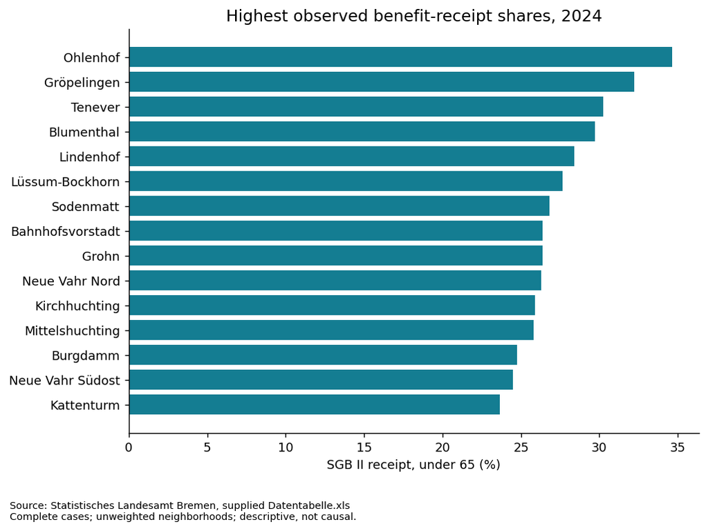

2024 under-65 SGB II receipt; percent; highest 15 observed shares.

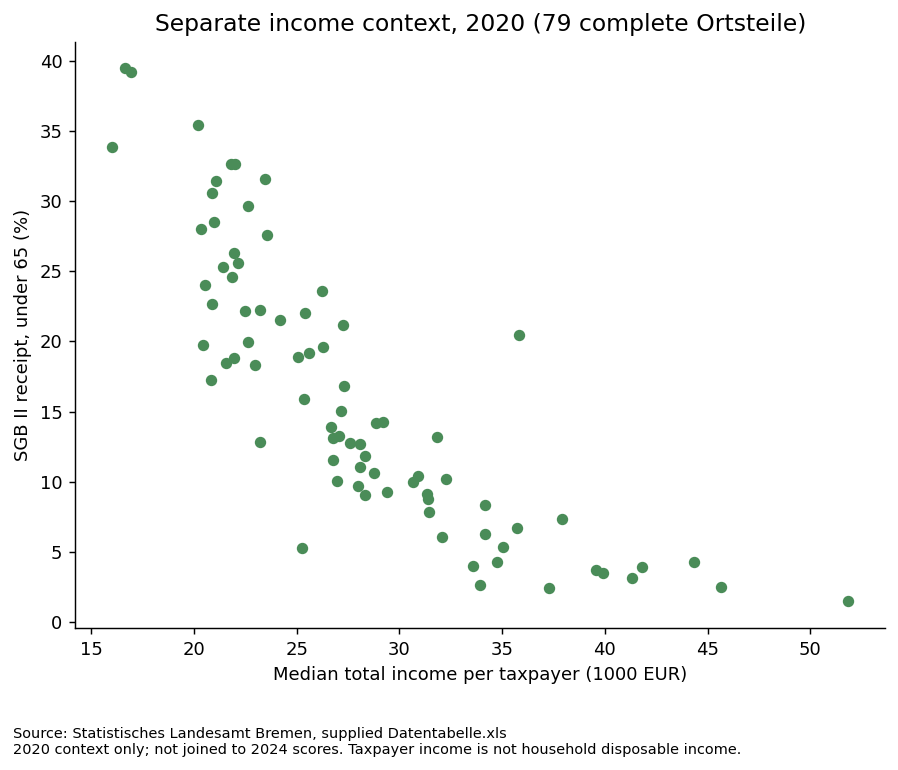

2020 only; median income per taxpayer in 1000 EUR; SGB II receipt in percent.

## 5. Composite Index

Directed min-max normalization; equal weights (1/3 each); score 0-1; descending competition ranks.

### Complete composite scores and ranks, 2024; score 0-1

| geo_code | geo_name | year | composite_score | rank |
| --- | --- | --- | --- | --- |
| 443 | Ohlenhof | 2024 | 0.943 | 1 |
| 442 | Gröpelingen | 2024 | 0.876 | 2 |
| 522 | Grohn | 2024 | 0.821 | 3 |
| 531 | Blumenthal | 2024 | 0.795 | 4 |
| 441 | Lindenhof | 2024 | 0.777 | 5 |
| 373 | Tenever | 2024 | 0.769 | 6 |
| 533 | Lüssum-Bockhorn | 2024 | 0.724 | 7 |
| 243 | Kirchhuchting | 2024 | 0.708 | 8 |
| 112 | Bahnhofsvorstadt | 2024 | 0.698 | 9 |
| 525 | Fähr-Lobbendorf | 2024 | 0.693 | 10 |
| 242 | Sodenmatt | 2024 | 0.669 | 11 |
| 332 | Neue Vahr Nord | 2024 | 0.642 | 12 |
| 217 | Neuenland | 2024 | 0.639 | 13 |
| 241 | Mittelshuchting | 2024 | 0.635 | 14 |
| 513 | Burgdamm | 2024 | 0.632 | 15 |
| 437 | Ueberseestadt | 2024 | 0.626 | 16 |
| 233 | Kattenturm | 2024 | 0.626 | 17 |
| 445 | Oslebshausen | 2024 | 0.620 | 18 |
| 218 | Huckelriede | 2024 | 0.596 | 19 |
| 521 | Vegesack | 2024 | 0.595 | 20 |
| 383 | Hemelingen | 2024 | 0.590 | 21 |
| 335 | Neue Vahr Südost | 2024 | 0.578 | 22 |
| 524 | Aumund-Hammersbeck | 2024 | 0.555 | 23 |
| 435 | Osterfeuerberg | 2024 | 0.542 | 24 |
| 375 | Blockdiek | 2024 | 0.538 | 25 |
| 433 | Westend | 2024 | 0.506 | 26 |
| 434 | Walle | 2024 | 0.494 | 27 |
| 532 | Rönnebeck | 2024 | 0.481 | 28 |
| 212 | Hohentor | 2024 | 0.471 | 29 |
| 251 | Woltmershausen | 2024 | 0.457 | 30 |
| 534 | Farge | 2024 | 0.441 | 31 |
| 511 | Burg-Grambke | 2024 | 0.439 | 32 |
| 514 | Lesum | 2024 | 0.438 | 33 |
| 431 | Utbremen | 2024 | 0.432 | 34 |
| 372 | Ellenerbrok-Schevemoor | 2024 | 0.429 | 35 |
| 334 | Neue Vahr Südwest | 2024 | 0.425 | 36 |
| 432 | Steffensweg | 2024 | 0.422 | 37 |
| 515 | St. Magnus | 2024 | 0.379 | 38 |
| 215 | Gartenstadt Süd | 2024 | 0.378 | 39 |
| 381 | Sebaldsbrück | 2024 | 0.372 | 40 |
| 523 | Schönebeck | 2024 | 0.369 | 41 |
| 113 | Ostertor | 2024 | 0.368 | 42 |
| 382 | Hastedt | 2024 | 0.358 | 43 |
| 214 | Südervorstadt | 2024 | 0.339 | 44 |
| 211 | Alte Neustadt | 2024 | 0.324 | 45 |
| 421 | Regensburger Straße | 2024 | 0.323 | 46 |
| 111 | Altstadt | 2024 | 0.321 | 47 |
| 314 | Hulsberg | 2024 | 0.320 | 48 |
| 342 | Lehe | 2024 | 0.317 | 49 |
| 213 | Neustadt | 2024 | 0.310 | 50 |
| 311 | Steintor | 2024 | 0.305 | 51 |
| 331 | Gartenstadt Vahr | 2024 | 0.298 | 52 |
| 371 | Ellener Feld | 2024 | 0.296 | 53 |
| 385 | Mahndorf | 2024 | 0.292 | 54 |
| 216 | Buntentor | 2024 | 0.286 | 55 |
| 234 | Kattenesch | 2024 | 0.272 | 56 |
| 422 | Findorff-Bürgerweide | 2024 | 0.271 | 57 |
| 232 | Arsten | 2024 | 0.270 | 58 |
| 312 | Fesenfeld | 2024 | 0.260 | 59 |
| 361 | Oberneuland | 2024 | 0.259 | 60 |
| 343 | Lehesterdeich | 2024 | 0.256 | 61 |
| 423 | Weidedamm | 2024 | 0.255 | 62 |
| 325 | Radio Bremen | 2024 | 0.250 | 63 |
| 384 | Arbergen | 2024 | 0.243 | 64 |
| 322 | Bürgerpark | 2024 | 0.227 | 65 |
| 313 | Peterswerder | 2024 | 0.227 | 66 |
| 324 | Riensberg | 2024 | 0.221 | 67 |
| 321 | Neu-Schwachhausen | 2024 | 0.211 | 68 |
| 327 | Gete | 2024 | 0.208 | 69 |
| 535 | Rekum | 2024 | 0.206 | 70 |
| 351 | Borgfeld | 2024 | 0.194 | 71 |
| 341 | Horn | 2024 | 0.190 | 72 |
| 252 | Rablinghausen | 2024 | 0.184 | 73 |
| 326 | Schwachhausen | 2024 | 0.184 | 74 |
| 323 | Barkhof | 2024 | 0.170 | 75 |
| 244 | Grolland | 2024 | 0.165 | 76 |
| 374 | Osterholz | 2024 | 0.137 | 77 |
| 231 | Habenhausen | 2024 | 0.136 | 78 |
| 261 | Seehausen | 2024 | 0.012 | 79 |

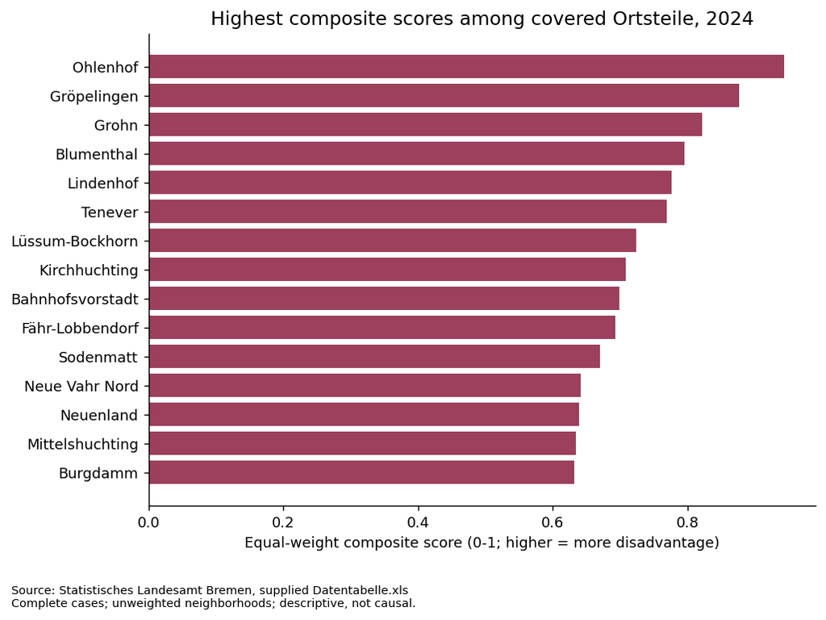

2024 composite scores; equal indicator weights; highest 15 scores.

### Directed normalized indicators, 2024; 0-1

| geo_code | geo_name | year | unemployment | employment | benefit_receipt |
| --- | --- | --- | --- | --- | --- |
| 111 | Altstadt | 2024 | 0.293 | 0.318 | 0.350 |
| 112 | Bahnhofsvorstadt | 2024 | 0.708 | 0.637 | 0.750 |
| 113 | Ostertor | 2024 | 0.287 | 0.584 | 0.233 |
| 211 | Alte Neustadt | 2024 | 0.328 | 0.338 | 0.307 |
| 212 | Hohentor | 2024 | 0.464 | 0.486 | 0.465 |
| 213 | Neustadt | 2024 | 0.238 | 0.466 | 0.226 |
| 214 | Südervorstadt | 2024 | 0.331 | 0.385 | 0.301 |
| 215 | Gartenstadt Süd | 2024 | 0.340 | 0.344 | 0.450 |
| 216 | Buntentor | 2024 | 0.263 | 0.366 | 0.228 |
| 217 | Neuenland | 2024 | 0.755 | 0.498 | 0.663 |
| 218 | Huckelriede | 2024 | 0.465 | 0.814 | 0.508 |
| 231 | Habenhausen | 2024 | 0.055 | 0.332 | 0.022 |
| 232 | Arsten | 2024 | 0.224 | 0.320 | 0.267 |
| 233 | Kattenturm | 2024 | 0.586 | 0.626 | 0.666 |
| 234 | Kattenesch | 2024 | 0.224 | 0.334 | 0.259 |
| 241 | Mittelshuchting | 2024 | 0.568 | 0.604 | 0.732 |
| 242 | Sodenmatt | 2024 | 0.630 | 0.614 | 0.764 |
| 243 | Kirchhuchting | 2024 | 0.656 | 0.734 | 0.735 |
| 244 | Grolland | 2024 | 0.103 | 0.312 | 0.081 |
| 251 | Woltmershausen | 2024 | 0.446 | 0.448 | 0.475 |
| 252 | Rablinghausen | 2024 | 0.260 | 0.011 | 0.282 |
| 261 | Seehausen | 2024 | 0.000 | 0.000 | 0.035 |
| 311 | Steintor | 2024 | 0.222 | 0.512 | 0.180 |
| 312 | Fesenfeld | 2024 | 0.196 | 0.433 | 0.151 |
| 313 | Peterswerder | 2024 | 0.162 | 0.401 | 0.118 |
| 314 | Hulsberg | 2024 | 0.299 | 0.381 | 0.280 |
| 321 | Neu-Schwachhausen | 2024 | 0.145 | 0.349 | 0.139 |
| 322 | Bürgerpark | 2024 | 0.094 | 0.544 | 0.044 |
| 323 | Barkhof | 2024 | 0.109 | 0.352 | 0.049 |
| 324 | Riensberg | 2024 | 0.139 | 0.388 | 0.136 |
| 325 | Radio Bremen | 2024 | 0.161 | 0.467 | 0.123 |
| 326 | Schwachhausen | 2024 | 0.064 | 0.437 | 0.050 |
| 327 | Gete | 2024 | 0.124 | 0.434 | 0.066 |
| 331 | Gartenstadt Vahr | 2024 | 0.264 | 0.349 | 0.281 |
| 332 | Neue Vahr Nord | 2024 | 0.618 | 0.560 | 0.746 |
| 334 | Neue Vahr Südwest | 2024 | 0.394 | 0.333 | 0.549 |
| 335 | Neue Vahr Südost | 2024 | 0.566 | 0.478 | 0.692 |
| 341 | Horn | 2024 | 0.079 | 0.433 | 0.056 |
| 342 | Lehe | 2024 | 0.164 | 0.650 | 0.138 |
| 343 | Lehesterdeich | 2024 | 0.190 | 0.359 | 0.218 |
| 351 | Borgfeld | 2024 | 0.034 | 0.547 | 0.000 |
| 361 | Oberneuland | 2024 | 0.115 | 0.578 | 0.084 |
| 371 | Ellener Feld | 2024 | 0.221 | 0.378 | 0.290 |
| 372 | Ellenerbrok-Schevemoor | 2024 | 0.371 | 0.444 | 0.473 |
| 373 | Tenever | 2024 | 0.689 | 0.750 | 0.867 |
| 374 | Osterholz | 2024 | 0.086 | 0.266 | 0.058 |
| 375 | Blockdiek | 2024 | 0.517 | 0.512 | 0.585 |
| 381 | Sebaldsbrück | 2024 | 0.336 | 0.418 | 0.363 |
| 382 | Hastedt | 2024 | 0.359 | 0.391 | 0.326 |
| 383 | Hemelingen | 2024 | 0.547 | 0.558 | 0.664 |
| 384 | Arbergen | 2024 | 0.162 | 0.317 | 0.250 |
| 385 | Mahndorf | 2024 | 0.269 | 0.283 | 0.324 |
| 421 | Regensburger Straße | 2024 | 0.264 | 0.402 | 0.303 |
| 422 | Findorff-Bürgerweide | 2024 | 0.236 | 0.305 | 0.273 |
| 423 | Weidedamm | 2024 | 0.185 | 0.369 | 0.211 |
| 431 | Utbremen | 2024 | 0.357 | 0.381 | 0.559 |
| 432 | Steffensweg | 2024 | 0.388 | 0.416 | 0.462 |
| 433 | Westend | 2024 | 0.441 | 0.587 | 0.489 |
| 434 | Walle | 2024 | 0.497 | 0.488 | 0.496 |
| 435 | Osterfeuerberg | 2024 | 0.542 | 0.592 | 0.491 |
| 437 | Ueberseestadt | 2024 | 0.462 | 0.878 | 0.538 |
| 441 | Lindenhof | 2024 | 0.786 | 0.732 | 0.811 |
| 442 | Gröpelingen | 2024 | 0.909 | 0.794 | 0.927 |
| 443 | Ohlenhof | 2024 | 1.000 | 0.828 | 1.000 |
| 445 | Oslebshausen | 2024 | 0.562 | 0.672 | 0.624 |
| 511 | Burg-Grambke | 2024 | 0.442 | 0.372 | 0.503 |
| 513 | Burgdamm | 2024 | 0.588 | 0.606 | 0.700 |
| 514 | Lesum | 2024 | 0.339 | 0.568 | 0.406 |
| 515 | St. Magnus | 2024 | 0.266 | 0.736 | 0.136 |
| 521 | Vegesack | 2024 | 0.547 | 0.635 | 0.604 |
| 522 | Grohn | 2024 | 0.716 | 0.999 | 0.749 |
| 523 | Schönebeck | 2024 | 0.299 | 0.480 | 0.329 |
| 524 | Aumund-Hammersbeck | 2024 | 0.526 | 0.586 | 0.552 |
| 525 | Fähr-Lobbendorf | 2024 | 0.594 | 1.000 | 0.485 |
| 531 | Blumenthal | 2024 | 0.777 | 0.756 | 0.852 |
| 532 | Rönnebeck | 2024 | 0.455 | 0.511 | 0.478 |
| 533 | Lüssum-Bockhorn | 2024 | 0.672 | 0.712 | 0.788 |
| 534 | Farge | 2024 | 0.425 | 0.412 | 0.486 |
| 535 | Rekum | 2024 | 0.160 | 0.269 | 0.190 |

## 6. TOPSIS

Column vector normalization; equal weights (1/3 each); Euclidean distance; descending closeness ranks.

### Complete TOPSIS closeness, ranks and normalized distances, 2024

| geo_code | geo_name | year | topsis_score | rank | distance_to_disadvantage_ideal | distance_to_advantage_ideal |
| --- | --- | --- | --- | --- | --- | --- |
| 443 | Ohlenhof | 2024 | 0.971 | 1 | 0.003 | 0.103 |
| 442 | Gröpelingen | 2024 | 0.911 | 2 | 0.009 | 0.095 |
| 531 | Blumenthal | 2024 | 0.810 | 3 | 0.020 | 0.084 |
| 441 | Lindenhof | 2024 | 0.796 | 4 | 0.021 | 0.082 |
| 373 | Tenever | 2024 | 0.767 | 5 | 0.025 | 0.081 |
| 522 | Grohn | 2024 | 0.738 | 6 | 0.027 | 0.077 |
| 533 | Lüssum-Bockhorn | 2024 | 0.726 | 7 | 0.029 | 0.076 |
| 112 | Bahnhofsvorstadt | 2024 | 0.726 | 8 | 0.028 | 0.075 |
| 217 | Neuenland | 2024 | 0.699 | 9 | 0.031 | 0.073 |
| 243 | Kirchhuchting | 2024 | 0.696 | 10 | 0.032 | 0.072 |
| 242 | Sodenmatt | 2024 | 0.691 | 11 | 0.032 | 0.072 |
| 332 | Neue Vahr Nord | 2024 | 0.676 | 12 | 0.034 | 0.071 |
| 241 | Mittelshuchting | 2024 | 0.645 | 13 | 0.037 | 0.068 |
| 513 | Burgdamm | 2024 | 0.642 | 14 | 0.037 | 0.067 |
| 233 | Kattenturm | 2024 | 0.626 | 15 | 0.039 | 0.065 |
| 335 | Neue Vahr Südost | 2024 | 0.623 | 16 | 0.039 | 0.065 |
| 383 | Hemelingen | 2024 | 0.603 | 17 | 0.041 | 0.063 |
| 445 | Oslebshausen | 2024 | 0.595 | 18 | 0.042 | 0.062 |
| 521 | Vegesack | 2024 | 0.577 | 19 | 0.044 | 0.060 |
| 525 | Fähr-Lobbendorf | 2024 | 0.551 | 20 | 0.047 | 0.058 |
| 375 | Blockdiek | 2024 | 0.550 | 21 | 0.047 | 0.057 |
| 524 | Aumund-Hammersbeck | 2024 | 0.541 | 22 | 0.048 | 0.056 |
| 435 | Osterfeuerberg | 2024 | 0.519 | 23 | 0.050 | 0.054 |
| 437 | Ueberseestadt | 2024 | 0.512 | 24 | 0.051 | 0.054 |
| 218 | Huckelriede | 2024 | 0.497 | 25 | 0.052 | 0.052 |
| 434 | Walle | 2024 | 0.496 | 26 | 0.052 | 0.051 |
| 511 | Burg-Grambke | 2024 | 0.470 | 27 | 0.055 | 0.049 |
| 433 | Westend | 2024 | 0.469 | 28 | 0.055 | 0.049 |
| 334 | Neue Vahr Südwest | 2024 | 0.469 | 29 | 0.056 | 0.049 |
| 532 | Rönnebeck | 2024 | 0.468 | 30 | 0.055 | 0.048 |
| 212 | Hohentor | 2024 | 0.465 | 31 | 0.055 | 0.048 |
| 251 | Woltmershausen | 2024 | 0.461 | 32 | 0.056 | 0.048 |
| 431 | Utbremen | 2024 | 0.459 | 33 | 0.057 | 0.048 |
| 534 | Farge | 2024 | 0.455 | 34 | 0.057 | 0.047 |
| 432 | Steffensweg | 2024 | 0.426 | 35 | 0.060 | 0.044 |
| 372 | Ellenerbrok-Schevemoor | 2024 | 0.424 | 36 | 0.060 | 0.044 |
| 215 | Gartenstadt Süd | 2024 | 0.396 | 37 | 0.063 | 0.041 |
| 514 | Lesum | 2024 | 0.380 | 38 | 0.064 | 0.040 |
| 381 | Sebaldsbrück | 2024 | 0.352 | 39 | 0.067 | 0.036 |
| 382 | Hastedt | 2024 | 0.344 | 40 | 0.068 | 0.036 |
| 111 | Altstadt | 2024 | 0.323 | 41 | 0.070 | 0.033 |
| 523 | Schönebeck | 2024 | 0.320 | 42 | 0.071 | 0.033 |
| 214 | Südervorstadt | 2024 | 0.318 | 43 | 0.071 | 0.033 |
| 211 | Alte Neustadt | 2024 | 0.318 | 44 | 0.071 | 0.033 |
| 385 | Mahndorf | 2024 | 0.297 | 45 | 0.073 | 0.031 |
| 314 | Hulsberg | 2024 | 0.292 | 46 | 0.073 | 0.030 |
| 421 | Regensburger Straße | 2024 | 0.288 | 47 | 0.074 | 0.030 |
| 331 | Gartenstadt Vahr | 2024 | 0.275 | 48 | 0.075 | 0.028 |
| 113 | Ostertor | 2024 | 0.274 | 49 | 0.076 | 0.029 |
| 252 | Rablinghausen | 2024 | 0.266 | 50 | 0.076 | 0.028 |
| 371 | Ellener Feld | 2024 | 0.262 | 51 | 0.077 | 0.027 |
| 422 | Findorff-Bürgerweide | 2024 | 0.257 | 52 | 0.077 | 0.027 |
| 216 | Buntentor | 2024 | 0.250 | 53 | 0.078 | 0.026 |
| 232 | Arsten | 2024 | 0.249 | 54 | 0.078 | 0.026 |
| 234 | Kattenesch | 2024 | 0.245 | 55 | 0.078 | 0.025 |
| 213 | Neustadt | 2024 | 0.242 | 56 | 0.079 | 0.025 |
| 515 | St. Magnus | 2024 | 0.236 | 57 | 0.082 | 0.025 |
| 311 | Steintor | 2024 | 0.216 | 58 | 0.082 | 0.023 |
| 384 | Arbergen | 2024 | 0.214 | 59 | 0.082 | 0.022 |
| 343 | Lehesterdeich | 2024 | 0.211 | 60 | 0.082 | 0.022 |
| 423 | Weidedamm | 2024 | 0.206 | 61 | 0.082 | 0.021 |
| 312 | Fesenfeld | 2024 | 0.186 | 62 | 0.085 | 0.019 |
| 342 | Lehe | 2024 | 0.183 | 63 | 0.087 | 0.019 |
| 535 | Rekum | 2024 | 0.179 | 64 | 0.085 | 0.019 |
| 325 | Radio Bremen | 2024 | 0.161 | 65 | 0.088 | 0.017 |
| 313 | Peterswerder | 2024 | 0.155 | 66 | 0.088 | 0.016 |
| 321 | Neu-Schwachhausen | 2024 | 0.152 | 67 | 0.088 | 0.016 |
| 324 | Riensberg | 2024 | 0.150 | 68 | 0.089 | 0.016 |
| 361 | Oberneuland | 2024 | 0.138 | 69 | 0.092 | 0.015 |
| 327 | Gete | 2024 | 0.121 | 70 | 0.093 | 0.013 |
| 322 | Bürgerpark | 2024 | 0.115 | 71 | 0.095 | 0.012 |
| 244 | Grolland | 2024 | 0.105 | 72 | 0.093 | 0.011 |
| 323 | Barkhof | 2024 | 0.101 | 73 | 0.095 | 0.011 |
| 341 | Horn | 2024 | 0.099 | 74 | 0.096 | 0.011 |
| 326 | Schwachhausen | 2024 | 0.093 | 75 | 0.097 | 0.010 |
| 351 | Borgfeld | 2024 | 0.093 | 76 | 0.100 | 0.010 |
| 374 | Osterholz | 2024 | 0.085 | 77 | 0.095 | 0.009 |
| 231 | Habenhausen | 2024 | 0.070 | 78 | 0.099 | 0.007 |
| 261 | Seehausen | 2024 | 0.024 | 79 | 0.102 | 0.003 |

### TOPSIS weights and ideal profiles

| indicator | weight | ideal_disadvantage | anti_ideal |
| --- | --- | --- | --- |
| unemployment | 0.333 | 0.079 | 0.007 |
| employment | 0.333 | 0.028 | 0.046 |
| benefit_receipt | 0.333 | 0.076 | 0.004 |

### TOPSIS weighted normalized matrix, 2024

| geo_code | geo_name | unemployment | employment | benefit_receipt |
| --- | --- | --- | --- | --- |
| 111 | Altstadt | 0.028 | 0.041 | 0.029 |
| 112 | Bahnhofsvorstadt | 0.058 | 0.035 | 0.058 |
| 113 | Ostertor | 0.028 | 0.036 | 0.021 |
| 211 | Alte Neustadt | 0.031 | 0.040 | 0.026 |
| 212 | Hohentor | 0.041 | 0.037 | 0.037 |
| 213 | Neustadt | 0.024 | 0.038 | 0.020 |
| 214 | Südervorstadt | 0.031 | 0.039 | 0.026 |
| 215 | Gartenstadt Süd | 0.032 | 0.040 | 0.036 |
| 216 | Buntentor | 0.026 | 0.040 | 0.020 |
| 217 | Neuenland | 0.061 | 0.037 | 0.052 |
| 218 | Huckelriede | 0.041 | 0.032 | 0.041 |
| 231 | Habenhausen | 0.011 | 0.040 | 0.005 |
| 232 | Arsten | 0.023 | 0.041 | 0.023 |
| 233 | Kattenturm | 0.049 | 0.035 | 0.052 |
| 234 | Kattenesch | 0.023 | 0.040 | 0.023 |
| 241 | Mittelshuchting | 0.048 | 0.035 | 0.057 |
| 242 | Sodenmatt | 0.053 | 0.035 | 0.059 |
| 243 | Kirchhuchting | 0.054 | 0.033 | 0.057 |
| 244 | Grolland | 0.015 | 0.041 | 0.010 |
| 251 | Woltmershausen | 0.039 | 0.038 | 0.038 |
| 252 | Rablinghausen | 0.026 | 0.046 | 0.024 |
| 261 | Seehausen | 0.007 | 0.046 | 0.006 |
| 311 | Steintor | 0.023 | 0.037 | 0.017 |
| 312 | Fesenfeld | 0.021 | 0.038 | 0.015 |
| 313 | Peterswerder | 0.019 | 0.039 | 0.012 |
| 314 | Hulsberg | 0.029 | 0.039 | 0.024 |
| 321 | Neu-Schwachhausen | 0.018 | 0.040 | 0.014 |
| 322 | Bürgerpark | 0.014 | 0.036 | 0.007 |
| 323 | Barkhof | 0.015 | 0.040 | 0.007 |
| 324 | Riensberg | 0.017 | 0.039 | 0.014 |
| 325 | Radio Bremen | 0.019 | 0.038 | 0.013 |
| 326 | Schwachhausen | 0.012 | 0.038 | 0.007 |
| 327 | Gete | 0.016 | 0.038 | 0.009 |
| 331 | Gartenstadt Vahr | 0.026 | 0.040 | 0.024 |
| 332 | Neue Vahr Nord | 0.052 | 0.036 | 0.058 |
| 334 | Neue Vahr Südwest | 0.036 | 0.040 | 0.044 |
| 335 | Neue Vahr Südost | 0.048 | 0.038 | 0.054 |
| 341 | Horn | 0.013 | 0.038 | 0.008 |
| 342 | Lehe | 0.019 | 0.034 | 0.014 |
| 343 | Lehesterdeich | 0.021 | 0.040 | 0.020 |
| 351 | Borgfeld | 0.010 | 0.036 | 0.004 |
| 361 | Oberneuland | 0.016 | 0.036 | 0.010 |
| 371 | Ellener Feld | 0.023 | 0.039 | 0.025 |
| 372 | Ellenerbrok-Schevemoor | 0.034 | 0.038 | 0.038 |
| 373 | Tenever | 0.057 | 0.033 | 0.067 |
| 374 | Osterholz | 0.014 | 0.041 | 0.008 |
| 375 | Blockdiek | 0.044 | 0.037 | 0.046 |
| 381 | Sebaldsbrück | 0.031 | 0.039 | 0.030 |
| 382 | Hastedt | 0.033 | 0.039 | 0.027 |
| 383 | Hemelingen | 0.047 | 0.036 | 0.052 |
| 384 | Arbergen | 0.019 | 0.041 | 0.022 |
| 385 | Mahndorf | 0.027 | 0.041 | 0.027 |
| 421 | Regensburger Straße | 0.026 | 0.039 | 0.026 |
| 422 | Findorff-Bürgerweide | 0.024 | 0.041 | 0.024 |
| 423 | Weidedamm | 0.021 | 0.040 | 0.019 |
| 431 | Utbremen | 0.033 | 0.039 | 0.044 |
| 432 | Steffensweg | 0.035 | 0.039 | 0.037 |
| 433 | Westend | 0.039 | 0.036 | 0.039 |
| 434 | Walle | 0.043 | 0.037 | 0.040 |
| 435 | Osterfeuerberg | 0.046 | 0.036 | 0.039 |
| 437 | Ueberseestadt | 0.041 | 0.030 | 0.043 |
| 441 | Lindenhof | 0.064 | 0.033 | 0.063 |
| 442 | Gröpelingen | 0.072 | 0.032 | 0.071 |
| 443 | Ohlenhof | 0.079 | 0.031 | 0.076 |
| 445 | Oslebshausen | 0.048 | 0.034 | 0.049 |
| 511 | Burg-Grambke | 0.039 | 0.040 | 0.040 |
| 513 | Burgdamm | 0.050 | 0.035 | 0.055 |
| 514 | Lesum | 0.032 | 0.036 | 0.033 |
| 515 | St. Magnus | 0.026 | 0.033 | 0.014 |
| 521 | Vegesack | 0.047 | 0.035 | 0.048 |
| 522 | Grohn | 0.059 | 0.028 | 0.058 |
| 523 | Schönebeck | 0.029 | 0.038 | 0.028 |
| 524 | Aumund-Hammersbeck | 0.045 | 0.036 | 0.044 |
| 525 | Fähr-Lobbendorf | 0.050 | 0.028 | 0.039 |
| 531 | Blumenthal | 0.063 | 0.033 | 0.066 |
| 532 | Rönnebeck | 0.040 | 0.037 | 0.038 |
| 533 | Lüssum-Bockhorn | 0.055 | 0.033 | 0.061 |
| 534 | Farge | 0.038 | 0.039 | 0.039 |
| 535 | Rekum | 0.019 | 0.041 | 0.018 |

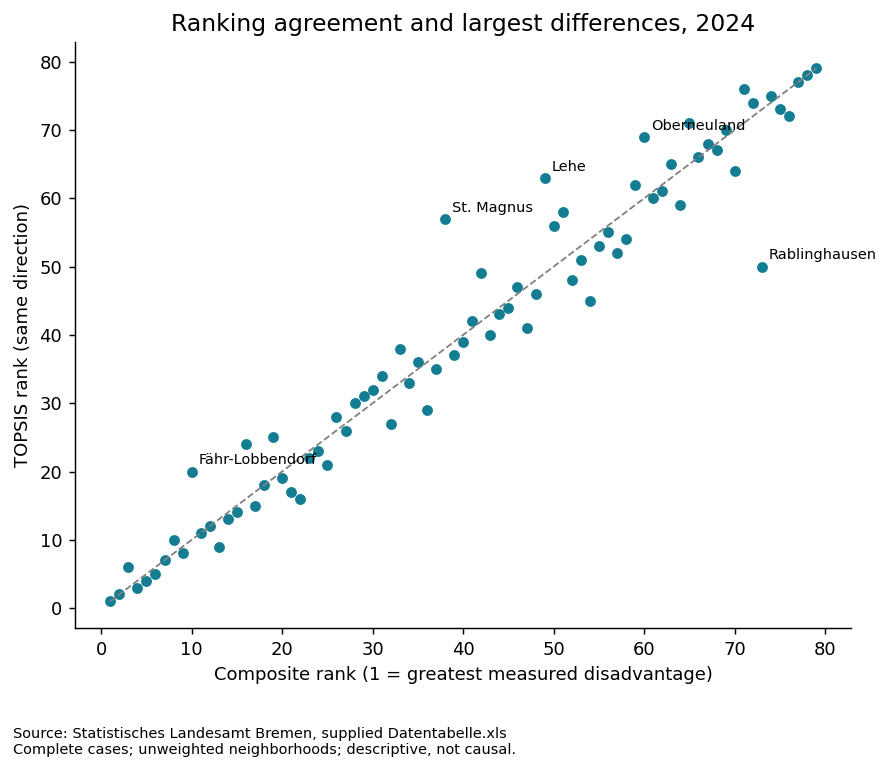

2024 TOPSIS and composite ranks.

## 7. K-means

StandardScaler (ddof=0); KMeans; k-means++; n_init=30; random_state=42; nominal profile labels.

### Cluster-count diagnostics

| k | silhouette | inertia | calinski_harabasz | davies_bouldin | minimum_cluster_size |
| --- | --- | --- | --- | --- | --- |
| 2 | 0.528 | 90.098 | 125.546 | 0.666 | 28 |
| 3 | 0.384 | 64.469 | 101.696 | 0.802 | 20 |
| 4 | 0.347 | 51.977 | 88.992 | 0.911 | 13 |
| 5 | 0.331 | 41.133 | 88.093 | 0.964 | 9 |
| 6 | 0.355 | 33.827 | 87.691 | 0.833 | 4 |
| 7 | 0.367 | 27.896 | 89.948 | 0.805 | 4 |
| 8 | 0.389 | 21.809 | 100.080 | 0.743 | 2 |

### Cluster sizes and mean percentages, 2024

| cluster | n | unemployment_mean | employment_mean | benefit_receipt_mean |
| --- | --- | --- | --- | --- |
| Profile A | 51 | 8.449 | 61.404 | 9.823 |
| Profile B | 28 | 18.077 | 53.579 | 23.989 |

### All cluster assignments, 2024; labels are nominal

| geo_code | geo_name | year | cluster |
| --- | --- | --- | --- |
| 111 | Altstadt | 2024 | Profile A |
| 113 | Ostertor | 2024 | Profile A |
| 211 | Alte Neustadt | 2024 | Profile A |
| 212 | Hohentor | 2024 | Profile A |
| 213 | Neustadt | 2024 | Profile A |
| 214 | Südervorstadt | 2024 | Profile A |
| 215 | Gartenstadt Süd | 2024 | Profile A |
| 216 | Buntentor | 2024 | Profile A |
| 231 | Habenhausen | 2024 | Profile A |
| 232 | Arsten | 2024 | Profile A |
| 234 | Kattenesch | 2024 | Profile A |
| 244 | Grolland | 2024 | Profile A |
| 251 | Woltmershausen | 2024 | Profile A |
| 252 | Rablinghausen | 2024 | Profile A |
| 261 | Seehausen | 2024 | Profile A |
| 311 | Steintor | 2024 | Profile A |
| 312 | Fesenfeld | 2024 | Profile A |
| 313 | Peterswerder | 2024 | Profile A |
| 314 | Hulsberg | 2024 | Profile A |
| 321 | Neu-Schwachhausen | 2024 | Profile A |
| 322 | Bürgerpark | 2024 | Profile A |
| 323 | Barkhof | 2024 | Profile A |
| 324 | Riensberg | 2024 | Profile A |
| 325 | Radio Bremen | 2024 | Profile A |
| 326 | Schwachhausen | 2024 | Profile A |
| 327 | Gete | 2024 | Profile A |
| 331 | Gartenstadt Vahr | 2024 | Profile A |
| 334 | Neue Vahr Südwest | 2024 | Profile A |
| 341 | Horn | 2024 | Profile A |
| 342 | Lehe | 2024 | Profile A |
| 343 | Lehesterdeich | 2024 | Profile A |
| 351 | Borgfeld | 2024 | Profile A |
| 361 | Oberneuland | 2024 | Profile A |
| 371 | Ellener Feld | 2024 | Profile A |
| 372 | Ellenerbrok-Schevemoor | 2024 | Profile A |
| 374 | Osterholz | 2024 | Profile A |
| 381 | Sebaldsbrück | 2024 | Profile A |
| 382 | Hastedt | 2024 | Profile A |
| 384 | Arbergen | 2024 | Profile A |
| 385 | Mahndorf | 2024 | Profile A |
| 421 | Regensburger Straße | 2024 | Profile A |
| 422 | Findorff-Bürgerweide | 2024 | Profile A |
| 423 | Weidedamm | 2024 | Profile A |
| 431 | Utbremen | 2024 | Profile A |
| 432 | Steffensweg | 2024 | Profile A |
| 511 | Burg-Grambke | 2024 | Profile A |
| 514 | Lesum | 2024 | Profile A |
| 515 | St. Magnus | 2024 | Profile A |
| 523 | Schönebeck | 2024 | Profile A |
| 534 | Farge | 2024 | Profile A |
| 535 | Rekum | 2024 | Profile A |
| 112 | Bahnhofsvorstadt | 2024 | Profile B |
| 217 | Neuenland | 2024 | Profile B |
| 218 | Huckelriede | 2024 | Profile B |
| 233 | Kattenturm | 2024 | Profile B |
| 241 | Mittelshuchting | 2024 | Profile B |
| 242 | Sodenmatt | 2024 | Profile B |
| 243 | Kirchhuchting | 2024 | Profile B |
| 332 | Neue Vahr Nord | 2024 | Profile B |
| 335 | Neue Vahr Südost | 2024 | Profile B |
| 373 | Tenever | 2024 | Profile B |
| 375 | Blockdiek | 2024 | Profile B |
| 383 | Hemelingen | 2024 | Profile B |
| 433 | Westend | 2024 | Profile B |
| 434 | Walle | 2024 | Profile B |
| 435 | Osterfeuerberg | 2024 | Profile B |
| 437 | Ueberseestadt | 2024 | Profile B |
| 441 | Lindenhof | 2024 | Profile B |
| 442 | Gröpelingen | 2024 | Profile B |
| 443 | Ohlenhof | 2024 | Profile B |
| 445 | Oslebshausen | 2024 | Profile B |
| 513 | Burgdamm | 2024 | Profile B |
| 521 | Vegesack | 2024 | Profile B |
| 522 | Grohn | 2024 | Profile B |
| 524 | Aumund-Hammersbeck | 2024 | Profile B |
| 525 | Fähr-Lobbendorf | 2024 | Profile B |
| 531 | Blumenthal | 2024 | Profile B |
| 532 | Rönnebeck | 2024 | Profile B |
| 533 | Lüssum-Bockhorn | 2024 | Profile B |

### unemployment cluster statistics, 2024; percent

| cluster | n | unemployment_mean | unemployment_std | unemployment_min | unemployment_max |
| --- | --- | --- | --- | --- | --- |
| Profile A | 51 | 8.449 | 2.904 | 2.590 | 14.162 |
| Profile B | 28 | 18.077 | 3.379 | 13.601 | 27.541 |

### employment cluster statistics, 2024; percent

| cluster | n | employment_mean | employment_std | employment_min | employment_max |
| --- | --- | --- | --- | --- | --- |
| Profile A | 51 | 61.404 | 3.583 | 51.704 | 72.714 |
| Profile B | 28 | 53.579 | 4.096 | 44.159 | 59.078 |

### benefit_receipt cluster statistics, 2024; percent

| cluster | n | benefit_receipt_mean | benefit_receipt_std | benefit_receipt_min | benefit_receipt_max |
| --- | --- | --- | --- | --- | --- |
| Profile A | 51 | 9.823 | 5.034 | 1.702 | 20.103 |
| Profile B | 28 | 23.989 | 4.712 | 17.436 | 34.622 |

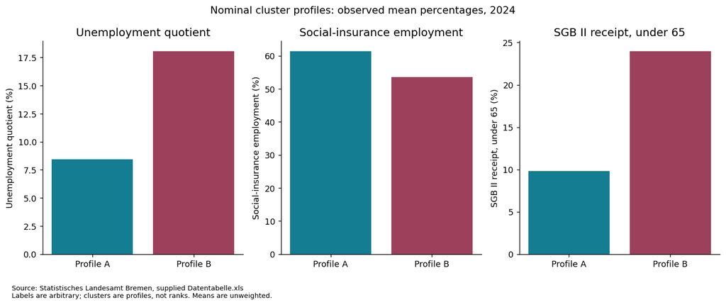

2024 cluster mean percentages; labels are nominal.

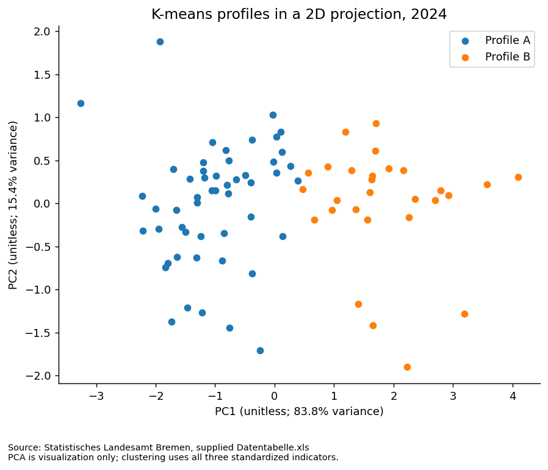

2024 PCA projection; standardized input; unitless coordinates.

### PCA explained variance ratios

| component | explained_variance_ratio |
| --- | --- |
| PC1 | 0.838 |
| PC2 | 0.154 |

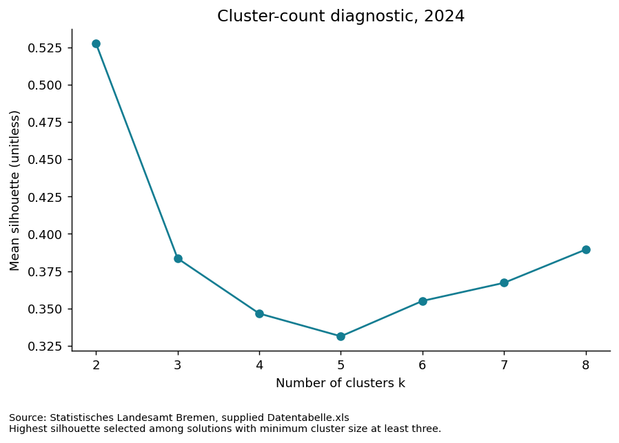

Silhouette by tested cluster count; unitless.

## 8. Ranking Comparison

Same 2024 row set and three indicators; rank 1 = greatest measured disadvantage.

### Rank agreement statistics, 2024

| spearman | kendall_tau_b | n |
| --- | --- | --- |
| 0.974 | 0.883 | 79 |

### All pairwise rank differences, 2024

| geo_code | geo_name | year | composite_rank | topsis_rank | rank_difference_topsis_minus_composite | absolute_rank_difference |
| --- | --- | --- | --- | --- | --- | --- |
| 252 | Rablinghausen | 2024 | 73.000 | 50.000 | -23.000 | 23.000 |
| 515 | St. Magnus | 2024 | 38.000 | 57.000 | 19.000 | 19.000 |
| 342 | Lehe | 2024 | 49.000 | 63.000 | 14.000 | 14.000 |
| 525 | Fähr-Lobbendorf | 2024 | 10.000 | 20.000 | 10.000 | 10.000 |
| 361 | Oberneuland | 2024 | 60.000 | 69.000 | 9.000 | 9.000 |
| 385 | Mahndorf | 2024 | 54.000 | 45.000 | -9.000 | 9.000 |
| 437 | Ueberseestadt | 2024 | 16.000 | 24.000 | 8.000 | 8.000 |
| 311 | Steintor | 2024 | 51.000 | 58.000 | 7.000 | 7.000 |
| 113 | Ostertor | 2024 | 42.000 | 49.000 | 7.000 | 7.000 |
| 334 | Neue Vahr Südwest | 2024 | 36.000 | 29.000 | -7.000 | 7.000 |
| 111 | Altstadt | 2024 | 47.000 | 41.000 | -6.000 | 6.000 |
| 218 | Huckelriede | 2024 | 19.000 | 25.000 | 6.000 | 6.000 |
| 322 | Bürgerpark | 2024 | 65.000 | 71.000 | 6.000 | 6.000 |
| 335 | Neue Vahr Südost | 2024 | 22.000 | 16.000 | -6.000 | 6.000 |
| 213 | Neustadt | 2024 | 50.000 | 56.000 | 6.000 | 6.000 |
| 535 | Rekum | 2024 | 70.000 | 64.000 | -6.000 | 6.000 |
| 514 | Lesum | 2024 | 33.000 | 38.000 | 5.000 | 5.000 |
| 511 | Burg-Grambke | 2024 | 32.000 | 27.000 | -5.000 | 5.000 |
| 422 | Findorff-Bürgerweide | 2024 | 57.000 | 52.000 | -5.000 | 5.000 |
| 384 | Arbergen | 2024 | 64.000 | 59.000 | -5.000 | 5.000 |
| 351 | Borgfeld | 2024 | 71.000 | 76.000 | 5.000 | 5.000 |
| 244 | Grolland | 2024 | 76.000 | 72.000 | -4.000 | 4.000 |
| 375 | Blockdiek | 2024 | 25.000 | 21.000 | -4.000 | 4.000 |
| 383 | Hemelingen | 2024 | 21.000 | 17.000 | -4.000 | 4.000 |
| 232 | Arsten | 2024 | 58.000 | 54.000 | -4.000 | 4.000 |
| 217 | Neuenland | 2024 | 13.000 | 9.000 | -4.000 | 4.000 |
| 331 | Gartenstadt Vahr | 2024 | 52.000 | 48.000 | -4.000 | 4.000 |
| 312 | Fesenfeld | 2024 | 59.000 | 62.000 | 3.000 | 3.000 |
| 534 | Farge | 2024 | 31.000 | 34.000 | 3.000 | 3.000 |
| 522 | Grohn | 2024 | 3.000 | 6.000 | 3.000 | 3.000 |
| 382 | Hastedt | 2024 | 43.000 | 40.000 | -3.000 | 3.000 |
| 432 | Steffensweg | 2024 | 37.000 | 35.000 | -2.000 | 2.000 |
| 532 | Rönnebeck | 2024 | 28.000 | 30.000 | 2.000 | 2.000 |
| 433 | Westend | 2024 | 26.000 | 28.000 | 2.000 | 2.000 |
| 341 | Horn | 2024 | 72.000 | 74.000 | 2.000 | 2.000 |
| 325 | Radio Bremen | 2024 | 63.000 | 65.000 | 2.000 | 2.000 |
| 216 | Buntentor | 2024 | 55.000 | 53.000 | -2.000 | 2.000 |
| 233 | Kattenturm | 2024 | 17.000 | 15.000 | -2.000 | 2.000 |
| 215 | Gartenstadt Süd | 2024 | 39.000 | 37.000 | -2.000 | 2.000 |
| 212 | Hohentor | 2024 | 29.000 | 31.000 | 2.000 | 2.000 |
| 371 | Ellener Feld | 2024 | 53.000 | 51.000 | -2.000 | 2.000 |
| 314 | Hulsberg | 2024 | 48.000 | 46.000 | -2.000 | 2.000 |
| 243 | Kirchhuchting | 2024 | 8.000 | 10.000 | 2.000 | 2.000 |
| 251 | Woltmershausen | 2024 | 30.000 | 32.000 | 2.000 | 2.000 |
| 323 | Barkhof | 2024 | 75.000 | 73.000 | -2.000 | 2.000 |
| 112 | Bahnhofsvorstadt | 2024 | 9.000 | 8.000 | -1.000 | 1.000 |
| 214 | Südervorstadt | 2024 | 44.000 | 43.000 | -1.000 | 1.000 |
| 523 | Schönebeck | 2024 | 41.000 | 42.000 | 1.000 | 1.000 |
| 234 | Kattenesch | 2024 | 56.000 | 55.000 | -1.000 | 1.000 |
| 211 | Alte Neustadt | 2024 | 45.000 | 44.000 | -1.000 | 1.000 |
| 531 | Blumenthal | 2024 | 4.000 | 3.000 | -1.000 | 1.000 |
| 431 | Utbremen | 2024 | 34.000 | 33.000 | -1.000 | 1.000 |
| 441 | Lindenhof | 2024 | 5.000 | 4.000 | -1.000 | 1.000 |
| 435 | Osterfeuerberg | 2024 | 24.000 | 23.000 | -1.000 | 1.000 |
| 434 | Walle | 2024 | 27.000 | 26.000 | -1.000 | 1.000 |
| 324 | Riensberg | 2024 | 67.000 | 68.000 | 1.000 | 1.000 |
| 326 | Schwachhausen | 2024 | 74.000 | 75.000 | 1.000 | 1.000 |
| 241 | Mittelshuchting | 2024 | 14.000 | 13.000 | -1.000 | 1.000 |
| 321 | Neu-Schwachhausen | 2024 | 68.000 | 67.000 | -1.000 | 1.000 |
| 343 | Lehesterdeich | 2024 | 61.000 | 60.000 | -1.000 | 1.000 |
| 327 | Gete | 2024 | 69.000 | 70.000 | 1.000 | 1.000 |
| 372 | Ellenerbrok-Schevemoor | 2024 | 35.000 | 36.000 | 1.000 | 1.000 |
| 373 | Tenever | 2024 | 6.000 | 5.000 | -1.000 | 1.000 |
| 421 | Regensburger Straße | 2024 | 46.000 | 47.000 | 1.000 | 1.000 |
| 524 | Aumund-Hammersbeck | 2024 | 23.000 | 22.000 | -1.000 | 1.000 |
| 521 | Vegesack | 2024 | 20.000 | 19.000 | -1.000 | 1.000 |
| 513 | Burgdamm | 2024 | 15.000 | 14.000 | -1.000 | 1.000 |
| 423 | Weidedamm | 2024 | 62.000 | 61.000 | -1.000 | 1.000 |
| 381 | Sebaldsbrück | 2024 | 40.000 | 39.000 | -1.000 | 1.000 |
| 231 | Habenhausen | 2024 | 78.000 | 78.000 | 0.000 | 0.000 |
| 242 | Sodenmatt | 2024 | 11.000 | 11.000 | 0.000 | 0.000 |
| 374 | Osterholz | 2024 | 77.000 | 77.000 | 0.000 | 0.000 |
| 332 | Neue Vahr Nord | 2024 | 12.000 | 12.000 | 0.000 | 0.000 |
| 261 | Seehausen | 2024 | 79.000 | 79.000 | 0.000 | 0.000 |
| 313 | Peterswerder | 2024 | 66.000 | 66.000 | 0.000 | 0.000 |
| 442 | Gröpelingen | 2024 | 2.000 | 2.000 | 0.000 | 0.000 |
| 443 | Ohlenhof | 2024 | 1.000 | 1.000 | 0.000 | 0.000 |
| 445 | Oslebshausen | 2024 | 18.000 | 18.000 | 0.000 | 0.000 |
| 533 | Lüssum-Bockhorn | 2024 | 7.000 | 7.000 | 0.000 | 0.000 |

## 9. Sensitivity and Stability

Fixed ranking sample; alternative weights and feature sets; 30 initialization and 30 bootstrap refits.

### Named sensitivity scenarios: feature sets and weight vectors

| scenario | method | features | weights |
| --- | --- | --- | --- |
| equal | composite | unemployment; employment; benefit_receipt | 0.33333333; 0.33333333; 0.33333333 |
| equal | topsis | unemployment; employment; benefit_receipt | 0.33333333; 0.33333333; 0.33333333 |
| domain_balanced | composite | unemployment; employment; benefit_receipt | 0.25000000; 0.25000000; 0.50000000 |
| domain_balanced | topsis | unemployment; employment; benefit_receipt | 0.25000000; 0.25000000; 0.50000000 |
| unemployment_emphasis | composite | unemployment; employment; benefit_receipt | 0.50000000; 0.25000000; 0.25000000 |
| unemployment_emphasis | topsis | unemployment; employment; benefit_receipt | 0.50000000; 0.25000000; 0.25000000 |
| employment_emphasis | composite | unemployment; employment; benefit_receipt | 0.25000000; 0.50000000; 0.25000000 |
| employment_emphasis | topsis | unemployment; employment; benefit_receipt | 0.25000000; 0.50000000; 0.25000000 |
| omit_unemployment | composite | employment; benefit_receipt | 0.50000000; 0.50000000 |
| omit_unemployment | topsis | employment; benefit_receipt | 0.50000000; 0.50000000 |
| omit_employment | composite | unemployment; benefit_receipt | 0.50000000; 0.50000000 |
| omit_employment | topsis | unemployment; benefit_receipt | 0.50000000; 0.50000000 |
| omit_benefit_receipt | composite | unemployment; employment | 0.50000000; 0.50000000 |
| omit_benefit_receipt | topsis | unemployment; employment | 0.50000000; 0.50000000 |
| include_child_benefits | composite | unemployment; employment; benefit_receipt; child_benefits | 0.25000000; 0.25000000; 0.25000000; 0.25000000 |
| include_child_benefits | topsis | unemployment; employment; benefit_receipt; child_benefits | 0.25000000; 0.25000000; 0.25000000; 0.25000000 |

### Named scenario rank robustness statistics

| scenario | method | spearman_vs_baseline | mean_absolute_rank_change | max_absolute_rank_change | top10_overlap | n |
| --- | --- | --- | --- | --- | --- | --- |
| equal | composite | 1.000 | 0.000 | 0.000 | 10 | 79 |
| equal | topsis | 1.000 | 0.000 | 0.000 | 10 | 79 |
| domain_balanced | composite | 0.994 | 1.722 | 8.000 | 9 | 79 |
| domain_balanced | topsis | 0.995 | 1.468 | 10.000 | 9 | 79 |
| unemployment_emphasis | composite | 0.997 | 1.190 | 7.000 | 10 | 79 |
| unemployment_emphasis | topsis | 0.997 | 1.241 | 5.000 | 10 | 79 |
| employment_emphasis | composite | 0.986 | 2.759 | 11.000 | 9 | 79 |
| employment_emphasis | topsis | 0.996 | 1.266 | 8.000 | 9 | 79 |
| omit_unemployment | composite | 0.991 | 2.278 | 9.000 | 9 | 79 |
| omit_unemployment | topsis | 0.993 | 1.873 | 10.000 | 9 | 79 |
| omit_employment | composite | 0.968 | 3.873 | 24.000 | 8 | 79 |
| omit_employment | topsis | 0.999 | 0.684 | 4.000 | 10 | 79 |
| omit_benefit_receipt | composite | 0.972 | 4.000 | 13.000 | 10 | 79 |
| omit_benefit_receipt | topsis | 0.992 | 2.127 | 12.000 | 10 | 79 |
| include_child_benefits | composite | 0.993 | 1.975 | 7.000 | 9 | 79 |
| include_child_benefits | topsis | 0.994 | 1.772 | 7.000 | 9 | 79 |

### 200 constrained random weight scenarios per method: summary

| method | scenarios | minimum_rank_correlation | mean_rank_correlation | maximum_rank_movement | minimum_top10_overlap |
| --- | --- | --- | --- | --- | --- |
| composite | 200 | 0.962 | 0.991 | 18.000 | 9 |
| topsis | 200 | 0.981 | 0.996 | 18.000 | 8 |

### Every random-weight scenario: calculated robustness statistics

| scenario | method | spearman_vs_baseline | mean_absolute_rank_change | max_absolute_rank_change | top10_overlap | n |
| --- | --- | --- | --- | --- | --- | --- |
| plausible_random_000 | composite | 0.991 | 2.152 | 8.000 | 10 | 79 |
| plausible_random_000 | topsis | 0.997 | 1.114 | 8.000 | 10 | 79 |
| plausible_random_001 | composite | 0.974 | 3.848 | 15.000 | 9 | 79 |
| plausible_random_001 | topsis | 0.989 | 2.203 | 14.000 | 10 | 79 |
| plausible_random_002 | composite | 0.998 | 0.937 | 5.000 | 9 | 79 |
| plausible_random_002 | topsis | 0.999 | 0.785 | 5.000 | 9 | 79 |
| plausible_random_003 | composite | 0.999 | 0.481 | 4.000 | 10 | 79 |
| plausible_random_003 | topsis | 0.998 | 0.886 | 5.000 | 9 | 79 |
| plausible_random_004 | composite | 0.990 | 2.203 | 11.000 | 9 | 79 |
| plausible_random_004 | topsis | 0.994 | 1.722 | 11.000 | 8 | 79 |
| plausible_random_005 | composite | 0.987 | 2.329 | 15.000 | 9 | 79 |
| plausible_random_005 | topsis | 0.998 | 1.089 | 4.000 | 10 | 79 |
| plausible_random_006 | composite | 0.970 | 4.127 | 15.000 | 9 | 79 |
| plausible_random_006 | topsis | 0.986 | 2.380 | 16.000 | 10 | 79 |
| plausible_random_007 | composite | 0.997 | 1.266 | 7.000 | 9 | 79 |
| plausible_random_007 | topsis | 0.997 | 1.241 | 5.000 | 10 | 79 |
| plausible_random_008 | composite | 0.992 | 1.975 | 10.000 | 9 | 79 |
| plausible_random_008 | topsis | 0.997 | 1.316 | 8.000 | 9 | 79 |
| plausible_random_009 | composite | 0.970 | 4.101 | 16.000 | 9 | 79 |
| plausible_random_009 | topsis | 0.991 | 2.000 | 10.000 | 9 | 79 |
| plausible_random_010 | composite | 0.994 | 1.620 | 10.000 | 9 | 79 |
| plausible_random_010 | topsis | 0.997 | 1.342 | 5.000 | 10 | 79 |
| plausible_random_011 | composite | 0.998 | 1.013 | 4.000 | 10 | 79 |
| plausible_random_011 | topsis | 0.998 | 0.987 | 7.000 | 10 | 79 |
| plausible_random_012 | composite | 1.000 | 0.278 | 2.000 | 10 | 79 |
| plausible_random_012 | topsis | 0.998 | 0.911 | 5.000 | 10 | 79 |
| plausible_random_013 | composite | 0.996 | 1.291 | 7.000 | 10 | 79 |
| plausible_random_013 | topsis | 0.994 | 1.696 | 10.000 | 9 | 79 |
| plausible_random_014 | composite | 0.993 | 1.797 | 11.000 | 9 | 79 |
| plausible_random_014 | topsis | 0.997 | 1.418 | 5.000 | 10 | 79 |

[output cut: 370 more lines]

### Neighborhood rank ranges across random weight scenarios; not confidence intervals

| geo_code | geo_name | min_composite | min_topsis | max_composite | max_topsis | median_composite | median_topsis |
| --- | --- | --- | --- | --- | --- | --- | --- |
| 111 | Altstadt | 42.000 | 40.000 | 59.000 | 47.000 | 48.000 | 42.000 |
| 112 | Bahnhofsvorstadt | 7.000 | 7.000 | 12.000 | 9.000 | 10.000 | 8.000 |
| 113 | Ostertor | 32.000 | 42.000 | 48.000 | 55.000 | 40.000 | 48.000 |
| 211 | Alte Neustadt | 43.000 | 41.000 | 55.000 | 47.000 | 47.000 | 43.000 |
| 212 | Hohentor | 29.000 | 27.000 | 31.000 | 35.000 | 29.000 | 31.000 |
| 213 | Neustadt | 45.000 | 49.000 | 53.000 | 57.000 | 49.000 | 55.000 |
| 214 | Südervorstadt | 42.000 | 41.000 | 49.000 | 45.000 | 44.000 | 43.000 |
| 215 | Gartenstadt Süd | 38.000 | 37.000 | 48.000 | 41.000 | 39.500 | 37.000 |
| 216 | Buntentor | 51.000 | 51.000 | 59.000 | 58.000 | 55.000 | 54.000 |
| 217 | Neuenland | 9.000 | 5.000 | 21.000 | 16.000 | 14.000 | 10.000 |
| 218 | Huckelriede | 11.000 | 23.000 | 25.000 | 28.000 | 19.000 | 25.000 |
| 231 | Habenhausen | 76.000 | 77.000 | 78.000 | 78.000 | 77.000 | 78.000 |
| 232 | Arsten | 52.000 | 52.000 | 66.000 | 59.000 | 58.000 | 54.000 |
| 233 | Kattenturm | 14.000 | 14.000 | 18.000 | 16.000 | 16.000 | 15.000 |
| 234 | Kattenesch | 55.000 | 53.000 | 63.000 | 58.000 | 57.000 | 55.000 |
| 241 | Mittelshuchting | 12.000 | 12.000 | 19.000 | 16.000 | 14.000 | 13.000 |
| 242 | Sodenmatt | 10.000 | 7.000 | 13.000 | 11.000 | 11.000 | 11.000 |
| 243 | Kirchhuchting | 8.000 | 8.000 | 10.000 | 11.000 | 9.000 | 10.000 |
| 244 | Grolland | 72.000 | 70.000 | 76.000 | 76.000 | 75.000 | 73.000 |
| 251 | Woltmershausen | 30.000 | 29.000 | 33.000 | 33.000 | 30.000 | 32.000 |
| 252 | Rablinghausen | 57.000 | 49.000 | 78.000 | 63.000 | 74.000 | 50.000 |
| 261 | Seehausen | 79.000 | 79.000 | 79.000 | 79.000 | 79.000 | 79.000 |
| 311 | Steintor | 42.000 | 52.000 | 58.000 | 61.000 | 51.000 | 58.000 |
| 312 | Fesenfeld | 54.000 | 59.000 | 63.000 | 64.000 | 59.000 | 63.000 |
| 313 | Peterswerder | 61.000 | 65.000 | 68.000 | 70.000 | 66.000 | 67.000 |
| 314 | Hulsberg | 46.000 | 44.000 | 51.000 | 49.000 | 48.000 | 47.000 |
| 321 | Neu-Schwachhausen | 68.000 | 65.000 | 72.000 | 72.000 | 69.000 | 67.000 |
| 322 | Bürgerpark | 49.000 | 65.000 | 71.000 | 75.000 | 65.000 | 71.000 |
| 323 | Barkhof | 72.000 | 71.000 | 76.000 | 76.000 | 74.000 | 74.000 |
| 324 | Riensberg | 65.000 | 65.000 | 69.000 | 70.000 | 67.000 | 68.000 |
| 325 | Radio Bremen | 52.000 | 62.000 | 65.000 | 67.000 | 62.000 | 65.000 |
| 326 | Schwachhausen | 70.000 | 74.000 | 75.000 | 76.000 | 73.000 | 75.000 |
| 327 | Gete | 60.000 | 69.000 | 71.000 | 72.000 | 69.000 | 70.000 |
| 331 | Gartenstadt Vahr | 49.000 | 48.000 | 59.000 | 51.000 | 52.000 | 49.000 |
| 332 | Neue Vahr Nord | 11.000 | 10.000 | 19.000 | 13.000 | 13.000 | 12.000 |
| 334 | Neue Vahr Südwest | 29.000 | 23.000 | 44.000 | 33.000 | 36.000 | 30.000 |
| 335 | Neue Vahr Südost | 16.000 | 14.000 | 25.000 | 19.000 | 22.000 | 16.000 |
| 341 | Horn | 68.000 | 72.000 | 74.000 | 75.000 | 72.000 | 73.000 |
| 342 | Lehe | 34.000 | 50.000 | 62.000 | 64.000 | 46.000 | 63.000 |
| 343 | Lehesterdeich | 59.000 | 58.000 | 64.000 | 63.000 | 62.000 | 59.000 |
| 351 | Borgfeld | 54.000 | 67.000 | 77.000 | 78.000 | 71.000 | 75.000 |
| 361 | Oberneuland | 43.000 | 59.000 | 69.000 | 70.000 | 59.000 | 69.000 |
| 371 | Ellener Feld | 49.000 | 47.000 | 57.000 | 58.000 | 53.000 | 51.000 |
| 372 | Ellenerbrok-Schevemoor | 32.000 | 34.000 | 36.000 | 36.000 | 35.000 | 35.000 |
| 373 | Tenever | 4.000 | 3.000 | 7.000 | 8.000 | 6.000 | 5.000 |
| 374 | Osterholz | 76.000 | 73.000 | 78.000 | 78.000 | 77.000 | 77.000 |
| 375 | Blockdiek | 21.000 | 20.000 | 27.000 | 25.000 | 25.000 | 21.000 |
| 381 | Sebaldsbrück | 39.000 | 39.000 | 42.000 | 40.000 | 40.000 | 39.000 |
| 382 | Hastedt | 39.000 | 37.000 | 47.000 | 42.000 | 43.000 | 40.000 |
| 383 | Hemelingen | 17.000 | 17.000 | 21.000 | 20.000 | 21.000 | 17.000 |
| 384 | Arbergen | 58.000 | 54.000 | 72.000 | 67.000 | 64.000 | 59.000 |
| 385 | Mahndorf | 46.000 | 43.000 | 67.000 | 54.000 | 54.000 | 46.000 |
| 421 | Regensburger Straße | 45.000 | 44.000 | 50.000 | 49.000 | 47.000 | 47.000 |
| 422 | Findorff-Bürgerweide | 51.000 | 50.000 | 69.000 | 56.000 | 58.000 | 52.000 |
| 423 | Weidedamm | 60.000 | 59.000 | 63.000 | 64.000 | 61.000 | 61.000 |
| 431 | Utbremen | 29.000 | 22.000 | 40.000 | 37.000 | 34.000 | 33.000 |
| 432 | Steffensweg | 34.000 | 34.000 | 38.000 | 36.000 | 37.000 | 35.500 |
| 433 | Westend | 24.000 | 26.000 | 27.000 | 31.000 | 26.000 | 29.000 |
| 434 | Walle | 26.000 | 24.000 | 30.000 | 29.000 | 27.000 | 26.000 |
| 435 | Osterfeuerberg | 22.000 | 21.000 | 25.000 | 29.000 | 24.000 | 24.000 |
| 437 | Ueberseestadt | 8.000 | 20.000 | 22.000 | 26.000 | 14.500 | 23.000 |
| 441 | Lindenhof | 4.000 | 3.000 | 7.000 | 5.000 | 5.000 | 4.000 |
| 442 | Gröpelingen | 2.000 | 2.000 | 3.000 | 2.000 | 2.000 | 2.000 |
| 443 | Ohlenhof | 1.000 | 1.000 | 1.000 | 1.000 | 1.000 | 1.000 |
| 445 | Oslebshausen | 14.000 | 16.000 | 18.000 | 18.000 | 17.000 | 18.000 |
| 511 | Burg-Grambke | 30.000 | 26.000 | 39.000 | 33.000 | 33.000 | 30.000 |
| 513 | Burgdamm | 13.000 | 13.000 | 18.000 | 14.000 | 15.000 | 13.000 |
| 514 | Lesum | 29.000 | 36.000 | 37.000 | 39.000 | 32.000 | 38.000 |
| 515 | St. Magnus | 26.000 | 39.000 | 56.000 | 62.000 | 38.000 | 55.000 |
| 521 | Vegesack | 18.000 | 18.000 | 21.000 | 20.000 | 20.000 | 19.000 |
| 522 | Grohn | 2.000 | 5.000 | 6.000 | 8.000 | 3.000 | 6.000 |
| 523 | Schönebeck | 39.000 | 40.000 | 43.000 | 44.000 | 40.000 | 42.000 |
| 524 | Aumund-Hammersbeck | 21.000 | 21.000 | 24.000 | 24.000 | 23.000 | 22.000 |
| 525 | Fähr-Lobbendorf | 4.000 | 12.000 | 20.000 | 27.000 | 9.000 | 20.000 |
| 531 | Blumenthal | 3.000 | 3.000 | 5.000 | 4.000 | 4.000 | 3.000 |
| 532 | Rönnebeck | 27.000 | 27.000 | 29.000 | 32.000 | 28.000 | 29.000 |
| 533 | Lüssum-Bockhorn | 7.000 | 6.000 | 10.000 | 9.000 | 7.000 | 7.000 |
| 534 | Farge | 31.000 | 31.000 | 36.000 | 34.000 | 33.000 | 32.000 |
| 535 | Rekum | 64.000 | 61.000 | 74.000 | 72.000 | 70.000 | 64.000 |

### Initialization and bootstrap clustering stability: adjusted Rand index

| experiment | mean | min | max |
| --- | --- | --- | --- |
| bootstrap_neighborhoods | 0.892 | 0.591 | 1.000 |
| initialization | 1.000 | 1.000 | 1.000 |

### All clustering refit stability statistics

| experiment | seed | k | adjusted_rand_index |
| --- | --- | --- | --- |
| initialization | 0 | 2 | 1.000 |
| bootstrap_neighborhoods | 0 | 2 | 0.949 |
| initialization | 1 | 2 | 1.000 |
| bootstrap_neighborhoods | 1 | 2 | 0.591 |
| initialization | 2 | 2 | 1.000 |
| bootstrap_neighborhoods | 2 | 2 | 0.949 |
| initialization | 3 | 2 | 1.000 |
| bootstrap_neighborhoods | 3 | 2 | 1.000 |
| initialization | 4 | 2 | 1.000 |
| bootstrap_neighborhoods | 4 | 2 | 1.000 |
| initialization | 5 | 2 | 1.000 |
| bootstrap_neighborhoods | 5 | 2 | 0.949 |
| initialization | 6 | 2 | 1.000 |
| bootstrap_neighborhoods | 6 | 2 | 1.000 |
| initialization | 7 | 2 | 1.000 |
| bootstrap_neighborhoods | 7 | 2 | 0.949 |
| initialization | 8 | 2 | 1.000 |
| bootstrap_neighborhoods | 8 | 2 | 0.899 |
| initialization | 9 | 2 | 1.000 |
| bootstrap_neighborhoods | 9 | 2 | 0.949 |
| initialization | 10 | 2 | 1.000 |
| bootstrap_neighborhoods | 10 | 2 | 0.591 |
| initialization | 11 | 2 | 1.000 |
| bootstrap_neighborhoods | 11 | 2 | 0.899 |
| initialization | 12 | 2 | 1.000 |
| bootstrap_neighborhoods | 12 | 2 | 0.899 |
| initialization | 13 | 2 | 1.000 |
| bootstrap_neighborhoods | 13 | 2 | 0.851 |
| initialization | 14 | 2 | 1.000 |
| bootstrap_neighborhoods | 14 | 2 | 0.899 |
| initialization | 15 | 2 | 1.000 |
| bootstrap_neighborhoods | 15 | 2 | 0.899 |
| initialization | 16 | 2 | 1.000 |
| bootstrap_neighborhoods | 16 | 2 | 0.949 |
| initialization | 17 | 2 | 1.000 |
| bootstrap_neighborhoods | 17 | 2 | 1.000 |
| initialization | 18 | 2 | 1.000 |
| bootstrap_neighborhoods | 18 | 2 | 0.851 |
| initialization | 19 | 2 | 1.000 |
| bootstrap_neighborhoods | 19 | 2 | 0.949 |
| initialization | 20 | 2 | 1.000 |
| bootstrap_neighborhoods | 20 | 2 | 1.000 |
| initialization | 21 | 2 | 1.000 |
| bootstrap_neighborhoods | 21 | 2 | 0.899 |
| initialization | 22 | 2 | 1.000 |
| bootstrap_neighborhoods | 22 | 2 | 0.591 |
| initialization | 23 | 2 | 1.000 |
| bootstrap_neighborhoods | 23 | 2 | 0.949 |
| initialization | 24 | 2 | 1.000 |
| bootstrap_neighborhoods | 24 | 2 | 0.591 |
| initialization | 25 | 2 | 1.000 |
| bootstrap_neighborhoods | 25 | 2 | 0.899 |
| initialization | 26 | 2 | 1.000 |
| bootstrap_neighborhoods | 26 | 2 | 1.000 |
| initialization | 27 | 2 | 1.000 |
| bootstrap_neighborhoods | 27 | 2 | 0.899 |
| initialization | 28 | 2 | 1.000 |
| bootstrap_neighborhoods | 28 | 2 | 0.949 |
| initialization | 29 | 2 | 1.000 |
| bootstrap_neighborhoods | 29 | 2 | 0.949 |

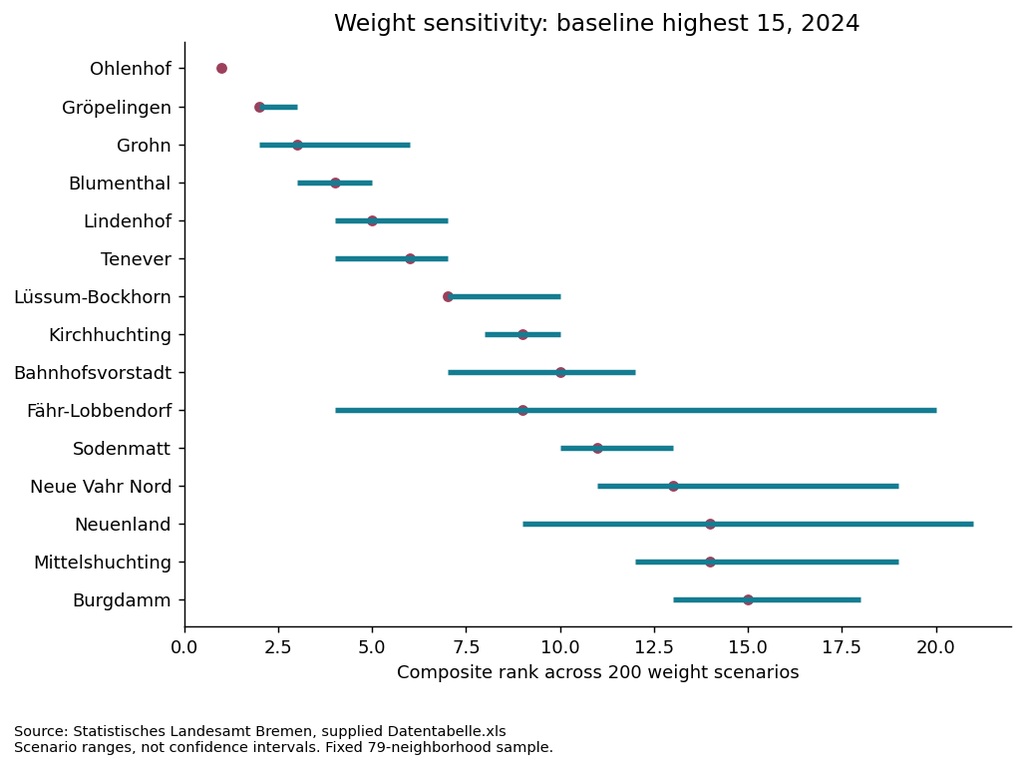

2024 composite rank ranges; 200 weight scenarios; baseline highest 15.

## 10. Four-Layer Architecture Diagram

Existing architecture figure.

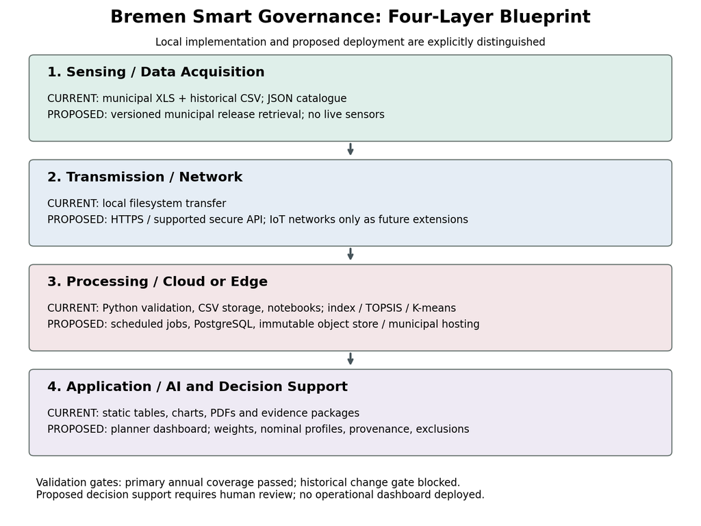

Existing four-layer architecture diagram.

## 11. Sources and Reproducibility

Saved results, source references, calculation settings and script links.

### Calculation settings

| Calculation | Setting |
| --- | --- |
| Primary inputs | 2024; complete cases; unemployment, employment, benefit_receipt |
| Composite | Min-max; employment reversed; equal weights; descending minimum-tie rank |
| TOPSIS | Vector normalization; equal weights; Euclidean distances; high unemployment/benefits and low employment ideal |
| K-means | StandardScaler; k=2..8; highest silhouette with minimum cluster size 3; n_init=30; seed=42 |
| Random weights | 200 draws; Dirichlet(3,3,3); weights constrained to [0.10,0.60]; seed=2024 |
| Cluster stability | 30 initialization seeds; 30 bootstrap neighborhood refits; ARI on fixed full sample |
| Display precision | 3 decimal places; stored CSV precision unchanged |

### Dataset references

| Source | Local file | Reference |
| --- | --- | --- |
| Primary statistics | Datentabelle.xls | https://www.statistik.bremen.de/datenangebote/bremer-ortsteilatlas-15228 |
| Historical CSV statistics | 22 ST*.csv files | data_inventory.csv |
| Catalogue metadata | bremen_data.json | data/processed/bremen_open_data_catalog.csv |
| Raw-source checksums | analysis/source_manifest.csv | SHA-256 |

### Scripts used

| Output | Script |
| --- | --- |
| Preparation | src/prepare_data.py |
| Analysis-ready dataset | src/build_analysis_dataset.py |
| Descriptive statistics | src/descriptive_analysis.py |
| Composite | src/composite_index.py |
| TOPSIS | src/topsis.py |
| K-means | src/clustering.py |
| Sensitivity | src/sensitivity_analysis.py |
| Figures and packages | src/package_results.py |
| Verification | src/verify_outputs.py |
| Results-only master exports | src/create_results_master.py |

src/prepare_data.py (src/prepare_data.py)  
src/build_analysis_dataset.py (src/build_analysis_dataset.py)  
src/descriptive_analysis.py (src/descriptive_analysis.py)  
src/composite_index.py (src/composite_index.py)  
src/topsis.py (src/topsis.py)  
src/clustering.py (src/clustering.py)  
src/sensitivity_analysis.py (src/sensitivity_analysis.py)  
src/package_results.py (src/package_results.py)  
src/verify_outputs.py (src/verify_outputs.py)  
src/create_results_master.py (src/create_results_master.py)

### Exact tested direct dependencies

| Package | Version |
| --- | --- |
| pandas | 2.3.2 |
| xlrd | 2.0.2 |
| numpy | 2.3.3 |
| scipy | 1.16.2 |
| scikit-learn | 1.7.2 |
| matplotlib | 3.10.6 |
| nbformat | 5.10.4 |
| nbclient | 0.10.2 |
| ipykernel | 7.1.0 |

Rebuild these documents only: python src/create_results_master.py

Full precision: results/*.csv. Full scenario scores: results/sensitivity_results.csv. Original calculation settings: docs/methods.md.